# Projet Econométrie SES 722

## Partie 1 : Régression

### Notes :

- Tous les tests d'hypothèses seront effectués à 5% sauf si un autre seuil de région de rejet est spécifié dans la question

```python
### Utils libs ###
import numpy as np
import pandas as pd

### ML Libs ###
from scipy.stats import t
from scipy import stats
import statsmodels.api as sm

### Data viz libs ###
import matplotlib.pyplot as plt
import seaborn as sns

# set the max columns to none
pd.set_option('display.max_columns', None)
```

## Question 1 :

*Lire le fichier `mroz.raw`. Ne sélectionner que les observations pour lesquelles la variable `wage` est **strictement positive**.*

#### Read `mroz.raw` et Renomage des colonnes

```python
# read mroz.raw file
df = pd.read_csv('textfiles/mroz.raw', delim_whitespace=True, header=None, index_col=None)

# rename columns
df = df.rename(columns={0: "inlf",            # =1 if in labor force, 1975
                        1: "hours",           # hours worked, 1975
                        2: "kidslt6",         # kids < 6 years
                        3: "kidsge6",         # kids 6-18
                        4: "age",             # woman's age in yrs
                        5: "educ",            # years of schooling
                        6: "wage",            # estimated wage from earns., hours
                        7: "repwage",         # reported wage at interview in 1976
                        8: "hushrs",          # hours worked by husband, 1975
                        9: "husage",          # husband's age
                        10: "huseduc",        # husband's years of schooling
                        11: "huswage",        # husband's hourly wage, 1975
                        12: "faminc",         # family income, 1975
                        13: "mtr",            # fed. marginal tax rate facing woman
                        14: "motheduc",       # mother's years of schooling
                        15: "fatheduc",       # father's years of schooling
                        16: "unem",           # unem. rate in county of resid.
                        17: "city",           # =1 if live in SMSA
                        18: "exper",          # actual labor mkt exper
                        19: "nwifeinc",       # (faminc - wage*hours)/1000
                        20: "lwage",          # log(wage)
                        21: "expersq",        # exper²
                       })

df
```

|  | inlf | hours | kidslt6 | kidsge6 | age | educ | wage | repwage | hushrs | husage | huseduc | huswage | faminc | mtr | motheduc | fatheduc | unem | city | exper | nwifeinc | lwage | expersq |
| --- | --- | --- | --- | --- | --- | --- | --- | --- | --- | --- | --- | --- | --- | --- | --- | --- | --- | --- | --- | --- | --- | --- |
| 0 | 1 | 1610 | 1 | 0 | 32 | 12 | 3.354 | 2.65 | 2708 | 34 | 12 | 4.0288 | 16310 | 0.7215 | 12 | 7 | 5.0 | 0 | 14 | 10.910060 | 1.210154 | 196 |
| 1 | 1 | 1656 | 0 | 2 | 30 | 12 | 1.3889 | 2.65 | 2310 | 30 | 9 | 8.4416 | 21800 | 0.6615 | 7 | 7 | 11.0 | 1 | 5 | 19.499980 | .3285121 | 25 |
| 2 | 1 | 1980 | 1 | 3 | 35 | 12 | 4.5455 | 4.04 | 3072 | 40 | 12 | 3.5807 | 21040 | 0.6915 | 12 | 7 | 5.0 | 0 | 15 | 12.039910 | 1.514138 | 225 |
| 3 | 1 | 456 | 0 | 3 | 34 | 12 | 1.0965 | 3.25 | 1920 | 53 | 10 | 3.5417 | 7300 | 0.7815 | 7 | 7 | 5.0 | 0 | 6 | 6.799996 | .0921233 | 36 |
| 4 | 1 | 1568 | 1 | 2 | 31 | 14 | 4.5918 | 3.60 | 2000 | 32 | 12 | 10.0000 | 27300 | 0.6215 | 12 | 14 | 9.5 | 1 | 7 | 20.100060 | 1.524272 | 49 |
| ... | ... | ... | ... | ... | ... | ... | ... | ... | ... | ... | ... | ... | ... | ... | ... | ... | ... | ... | ... | ... | ... | ... |
| 748 | 0 | 0 | 0 | 2 | 40 | 13 | . | 0.00 | 3020 | 43 | 16 | 9.2715 | 28200 | 0.6215 | 10 | 10 | 9.5 | 1 | 5 | 28.200000 | . | 25 |
| 749 | 0 | 0 | 2 | 3 | 31 | 12 | . | 0.00 | 2056 | 33 | 12 | 4.8638 | 10000 | 0.7715 | 12 | 12 | 7.5 | 0 | 14 | 10.000000 | . | 196 |
| 750 | 0 | 0 | 0 | 0 | 43 | 12 | . | 0.00 | 2383 | 43 | 12 | 1.0898 | 9952 | 0.7515 | 10 | 3 | 7.5 | 0 | 4 | 9.952000 | . | 16 |
| 751 | 0 | 0 | 0 | 0 | 60 | 12 | . | 0.00 | 1705 | 55 | 8 | 12.4400 | 24984 | 0.6215 | 12 | 12 | 14.0 | 1 | 15 | 24.984000 | . | 225 |
| 752 | 0 | 0 | 0 | 3 | 39 | 9 | . | 0.00 | 3120 | 48 | 12 | 6.0897 | 28363 | 0.6915 | 7 | 7 | 11.0 | 1 | 12 | 28.363000 | . | 144 |

753 rows × 22 columns

#### Inspection du type des variables

```python
df.dtypes
```

```
inlf          int64
hours         int64
kidslt6       int64
kidsge6       int64
age           int64
educ          int64
wage         object
repwage     float64
hushrs        int64
husage        int64
huseduc       int64
huswage     float64
faminc        int64
mtr         float64
motheduc      int64
fatheduc      int64
unem        float64
city          int64
exper         int64
nwifeinc    float64
lwage        object
expersq       int64
dtype: object
```

On remarque que les variables `wage` et `lwage` ne sont pas de type flottant. Avant de pouvoir sélectionner les observations pour lesquelles `wage` > 0 il est nécéssaire de convertir la variable `wage` en `float`

#### Sélection des observations pour lesquelles `wage` > 0

```python
df["wage"].value_counts()
```

```
.         325
2           5
6.25        4
2.5         4
3.75        4
         ...
4.2347      1
3.445       1
7.0968      1
8.19        1
3.354       1
Name: wage, Length: 374, dtype: int64
```

### Commentaires

On remarque que les valeurs de la variable `wage` ne sont pas toujours un nombre. Par exemple, la variable `wage` contient 325 fois le caractère ".". A ce stade, il n'est pas possible de travailler avec cette variable. Pour pallier ce problème, l'idée est d'abord de remplacer les observations qui ne sont pas des nombres par des valeurs manquantes (NaN value) pour pouvoir ensuite réaliser la conversion en float des variables `wage` et `lwage` ($log(wage)$). Par la suite, on remplacera les *NaN* par la valeur "0"

```python
# conversion de la colonne salaire en float avec une stratégie de force brute puis remplir NaN par 0
df["wage"] = pd.to_numeric(df["wage"], errors='coerce').fillna(0, downcast='infer')

# conversion de la colonne lwage en float avec une stratégie de force brute puis remplir NaN par 0
df["lwage"] = pd.to_numeric(df["lwage"], errors='coerce').fillna(0, downcast='infer')

# sélection des observations où le salaire > 0
df = df[df.wage > 0]
df
```

|  | inlf | hours | kidslt6 | kidsge6 | age | educ | wage | repwage | hushrs | husage | huseduc | huswage | faminc | mtr | motheduc | fatheduc | unem | city | exper | nwifeinc | lwage | expersq |
| --- | --- | --- | --- | --- | --- | --- | --- | --- | --- | --- | --- | --- | --- | --- | --- | --- | --- | --- | --- | --- | --- | --- |
| 0 | 1 | 1610 | 1 | 0 | 32 | 12 | 3.3540 | 2.65 | 2708 | 34 | 12 | 4.0288 | 16310 | 0.7215 | 12 | 7 | 5.0 | 0 | 14 | 10.910060 | 1.210154 | 196 |
| 1 | 1 | 1656 | 0 | 2 | 30 | 12 | 1.3889 | 2.65 | 2310 | 30 | 9 | 8.4416 | 21800 | 0.6615 | 7 | 7 | 11.0 | 1 | 5 | 19.499980 | 0.328512 | 25 |
| 2 | 1 | 1980 | 1 | 3 | 35 | 12 | 4.5455 | 4.04 | 3072 | 40 | 12 | 3.5807 | 21040 | 0.6915 | 12 | 7 | 5.0 | 0 | 15 | 12.039910 | 1.514138 | 225 |
| 3 | 1 | 456 | 0 | 3 | 34 | 12 | 1.0965 | 3.25 | 1920 | 53 | 10 | 3.5417 | 7300 | 0.7815 | 7 | 7 | 5.0 | 0 | 6 | 6.799996 | 0.092123 | 36 |
| 4 | 1 | 1568 | 1 | 2 | 31 | 14 | 4.5918 | 3.60 | 2000 | 32 | 12 | 10.0000 | 27300 | 0.6215 | 12 | 14 | 9.5 | 1 | 7 | 20.100060 | 1.524272 | 49 |
| ... | ... | ... | ... | ... | ... | ... | ... | ... | ... | ... | ... | ... | ... | ... | ... | ... | ... | ... | ... | ... | ... | ... |
| 423 | 1 | 680 | 0 | 5 | 36 | 10 | 2.3118 | 0.00 | 3430 | 43 | 12 | 5.3061 | 19772 | 0.7215 | 7 | 7 | 7.5 | 0 | 2 | 18.199980 | 0.838027 | 4 |
| 424 | 1 | 2450 | 0 | 1 | 40 | 12 | 5.3061 | 6.50 | 2008 | 40 | 8 | 7.2709 | 35641 | 0.6215 | 7 | 7 | 5.0 | 1 | 21 | 22.641060 | 1.668857 | 441 |
| 425 | 1 | 2144 | 0 | 2 | 43 | 13 | 5.8675 | 0.00 | 2140 | 43 | 11 | 8.1776 | 34220 | 0.5815 | 7 | 7 | 7.5 | 1 | 22 | 21.640080 | 1.769429 | 484 |
| 426 | 1 | 1760 | 0 | 1 | 33 | 12 | 3.4091 | 3.21 | 3380 | 34 | 12 | 7.1006 | 30000 | 0.5815 | 12 | 16 | 11.0 | 1 | 14 | 23.999980 | 1.226448 | 196 |
| 427 | 1 | 490 | 0 | 1 | 30 | 12 | 4.0816 | 2.46 | 2430 | 33 | 11 | 6.5844 | 18000 | 0.6915 | 12 | 12 | 7.5 | 1 | 7 | 16.000020 | 1.406489 | 49 |

428 rows × 22 columns

#### En sélectionnant les observations pour lesquelles la variable `wage` > 0 on obtient un dataframe avec 428 observations contre (753 initialement)

## Question 2 :

*Faire les statistiques descriptives du salaire, de l’age et de l’éducation pour :*

- **1/** L’ensemble des femmes
- **2/** Pour les femmes dont le salaire du mari est supérieure au 65ème percentile de l’échantillon
- **3/** Pour les femmes dont le salaire du mari est inférieur au 65ème percentile de l’échantillon.

*Commenter*

#### Statistique descriptives du *salaire* (`wage`), de l'âge (`age`) et l'éducation (`educ`) de l'ensemble des femmes

```python
print("#### Statistique descriptives du salaire (wage) pour l'ensemble des femmes ####\n")
print(df.wage.describe())

print("\n\n#### Statistique descriptives de l'âge (age) pour l'ensemble des femmes ####\n")
print(df.age.describe())

print("\n\n#### Statistique descriptives de l'éducaton (educ) pour l'ensemble des femmes ####\n")
print(df.educ.describe())
```

```
#### Statistique descriptives du salaire (wage) pour l'ensemble des femmes ####

count    428.000000
mean       4.177682
std        3.310282
min        0.128200
25%        2.262600
50%        3.481900
75%        4.970750
max       25.000000
Name: wage, dtype: float64


#### Statistique descriptives de l'âge (age) pour l'ensemble des femmes ####

count    428.000000
mean      41.971963
std        7.721084
min       30.000000
25%       35.000000
50%       42.000000
75%       47.250000
max       60.000000
Name: age, dtype: float64


#### Statistique descriptives de l'éducaton (educ) pour l'ensemble des femmes ####

count    428.000000
mean      12.658879
std        2.285376
min        5.000000
25%       12.000000
50%       12.000000
75%       14.000000
max       17.000000
Name: educ, dtype: float64
```

#### Statistique descriptives du *salaire* (`wage`), de l'âge (`age`) et l'éducation (`educ`) pour les femmes dont le salaire du mari est supérieure au 65ème percentile de l’échantillon

#### Calcul de 65ème quantile du salaire du mari. `huswage`

```python
huswage_65_quantile = df["huswage"].quantile(0.65)
huswage_65_quantile
```

```
7.8125
```

#### Sélection des observations dont le salaire du mari (`huswage`) est supérieure au 65ème percentile

```python
df_sup_65quantile = df[df.huswage > huswage_65_quantile]
df_sup_65quantile
```

|  | inlf | hours | kidslt6 | kidsge6 | age | educ | wage | repwage | hushrs | husage | huseduc | huswage | faminc | mtr | motheduc | fatheduc | unem | city | exper | nwifeinc | lwage | expersq |
| --- | --- | --- | --- | --- | --- | --- | --- | --- | --- | --- | --- | --- | --- | --- | --- | --- | --- | --- | --- | --- | --- | --- |
| 1 | 1 | 1656 | 0 | 2 | 30 | 12 | 1.3889 | 2.65 | 2310 | 30 | 9 | 8.4416 | 21800 | 0.6615 | 7 | 7 | 11.0 | 1 | 5 | 19.49998 | 0.328512 | 25 |
| 4 | 1 | 1568 | 1 | 2 | 31 | 14 | 4.5918 | 3.60 | 2000 | 32 | 12 | 10.0000 | 27300 | 0.6215 | 12 | 14 | 9.5 | 1 | 7 | 20.10006 | 1.524272 | 49 |
| 10 | 1 | 1969 | 0 | 1 | 33 | 12 | 4.0630 | 4.30 | 2450 | 34 | 12 | 9.7959 | 32300 | 0.5815 | 12 | 3 | 5.0 | 0 | 15 | 24.29995 | 1.401922 | 225 |
| 11 | 1 | 1960 | 0 | 1 | 42 | 11 | 4.5918 | 4.58 | 2375 | 47 | 14 | 8.0000 | 28700 | 0.6215 | 14 | 7 | 5.0 | 0 | 14 | 19.70007 | 1.524272 | 196 |
| 14 | 1 | 1848 | 0 | 1 | 43 | 10 | 3.6797 | 3.38 | 2024 | 45 | 17 | 10.8700 | 31431 | 0.5815 | 7 | 7 | 7.5 | 1 | 6 | 24.63091 | 1.302831 | 36 |
| ... | ... | ... | ... | ... | ... | ... | ... | ... | ... | ... | ... | ... | ... | ... | ... | ... | ... | ... | ... | ... | ... | ... |
| 407 | 1 | 120 | 1 | 3 | 36 | 12 | 25.0000 | 9.98 | 2500 | 35 | 12 | 8.4000 | 24000 | 0.6615 | 12 | 10 | 9.5 | 1 | 4 | 21.00000 | 3.218876 | 16 |
| 411 | 1 | 225 | 1 | 2 | 40 | 17 | 1.7778 | 0.00 | 1278 | 38 | 17 | 19.5620 | 25490 | 0.6615 | 16 | 17 | 14.0 | 1 | 8 | 25.08999 | 0.575377 | 64 |
| 415 | 1 | 1170 | 1 | 2 | 39 | 13 | 0.2137 | 0.00 | 1920 | 47 | 12 | 7.8646 | 16370 | 0.7215 | 12 | 16 | 11.0 | 1 | 1 | 16.11997 | -1.543182 | 1 |
| 422 | 1 | 460 | 2 | 0 | 32 | 17 | 4.7826 | 0.00 | 1850 | 31 | 17 | 8.1081 | 17300 | 0.7215 | 7 | 7 | 7.5 | 0 | 14 | 15.10000 | 1.564984 | 196 |
| 425 | 1 | 2144 | 0 | 2 | 43 | 13 | 5.8675 | 0.00 | 2140 | 43 | 11 | 8.1776 | 34220 | 0.5815 | 7 | 7 | 7.5 | 1 | 22 | 21.64008 | 1.769429 | 484 |

148 rows × 22 columns

```python
print("#### Statistique descriptives du salaire (wage) pour les femmes dont le salaire du mari est supérieure au 65ème percentile de l’échantillon ####\n")
print(df_sup_65quantile.wage.describe())

print("\n\n#### Statistique descriptives de l'âge (age) pour les femmes dont le salaire du mari est supérieure au 65ème percentile de l’échantillon ####\n")
print(df_sup_65quantile.age.describe())

print("\n\n#### Statistique descriptives de l'éducaton (educ) pour les femmes dont le salaire du mari est supérieure au 65ème percentile de l’échantillon ####\n")
print(df_sup_65quantile.educ.describe())
```

```
#### Statistique descriptives du salaire (wage) pour les femmes dont le salaire du mari est supérieure au 65ème percentile de l’échantillon ####

count    148.000000
mean       5.139315
std        4.351728
min        0.213700
25%        2.561925
50%        4.008050
75%        6.516300
max       25.000000
Name: wage, dtype: float64


#### Statistique descriptives de l'âge (age) pour les femmes dont le salaire du mari est supérieure au 65ème percentile de l’échantillon ####

count    148.00000
mean      42.52027
std        7.35168
min       30.00000
25%       36.00000
50%       43.00000
75%       48.00000
max       59.00000
Name: age, dtype: float64


#### Statistique descriptives de l'éducaton (educ) pour les femmes dont le salaire du mari est supérieure au 65ème percentile de l’échantillon ####

count    148.000000
mean      13.520270
std        2.345845
min        5.000000
25%       12.000000
50%       13.000000
75%       16.000000
max       17.000000
Name: educ, dtype: float64
```

#### Statistique descriptives du *salaire* (`wage`), de l'âge (`age`) et l'éducation (`educ`) pour les femmes dont le salaire du mari est inférieure au 65ème percentile de l’échantillon

#### Sélection des observations dont le salaire du mari (`huswage`) est inférieure au 65ème percentile

```python
df_inf_65quantile = df[df.huswage <= huswage_65_quantile]
df_inf_65quantile
```

|  | inlf | hours | kidslt6 | kidsge6 | age | educ | wage | repwage | hushrs | husage | huseduc | huswage | faminc | mtr | motheduc | fatheduc | unem | city | exper | nwifeinc | lwage | expersq |
| --- | --- | --- | --- | --- | --- | --- | --- | --- | --- | --- | --- | --- | --- | --- | --- | --- | --- | --- | --- | --- | --- | --- |
| 0 | 1 | 1610 | 1 | 0 | 32 | 12 | 3.3540 | 2.65 | 2708 | 34 | 12 | 4.0288 | 16310 | 0.7215 | 12 | 7 | 5.0 | 0 | 14 | 10.910060 | 1.210154 | 196 |
| 2 | 1 | 1980 | 1 | 3 | 35 | 12 | 4.5455 | 4.04 | 3072 | 40 | 12 | 3.5807 | 21040 | 0.6915 | 12 | 7 | 5.0 | 0 | 15 | 12.039910 | 1.514138 | 225 |
| 3 | 1 | 456 | 0 | 3 | 34 | 12 | 1.0965 | 3.25 | 1920 | 53 | 10 | 3.5417 | 7300 | 0.7815 | 7 | 7 | 5.0 | 0 | 6 | 6.799996 | 0.092123 | 36 |
| 5 | 1 | 2032 | 0 | 0 | 54 | 12 | 4.7421 | 4.70 | 1040 | 57 | 11 | 6.7106 | 19495 | 0.6915 | 14 | 7 | 7.5 | 1 | 33 | 9.859054 | 1.556480 | 1089 |
| 6 | 1 | 1440 | 0 | 2 | 37 | 16 | 8.3333 | 5.95 | 2670 | 37 | 12 | 3.4277 | 21152 | 0.6915 | 14 | 7 | 5.0 | 0 | 11 | 9.152048 | 2.120260 | 121 |
| ... | ... | ... | ... | ... | ... | ... | ... | ... | ... | ... | ... | ... | ... | ... | ... | ... | ... | ... | ... | ... | ... | ... |
| 421 | 1 | 50 | 1 | 1 | 45 | 12 | 3.4600 | 5.00 | 1780 | 46 | 10 | 6.7416 | 23882 | 0.7215 | 7 | 7 | 9.5 | 1 | 9 | 23.709000 | 1.241269 | 81 |
| 423 | 1 | 680 | 0 | 5 | 36 | 10 | 2.3118 | 0.00 | 3430 | 43 | 12 | 5.3061 | 19772 | 0.7215 | 7 | 7 | 7.5 | 0 | 2 | 18.199980 | 0.838027 | 4 |
| 424 | 1 | 2450 | 0 | 1 | 40 | 12 | 5.3061 | 6.50 | 2008 | 40 | 8 | 7.2709 | 35641 | 0.6215 | 7 | 7 | 5.0 | 1 | 21 | 22.641060 | 1.668857 | 441 |
| 426 | 1 | 1760 | 0 | 1 | 33 | 12 | 3.4091 | 3.21 | 3380 | 34 | 12 | 7.1006 | 30000 | 0.5815 | 12 | 16 | 11.0 | 1 | 14 | 23.999980 | 1.226448 | 196 |
| 427 | 1 | 490 | 0 | 1 | 30 | 12 | 4.0816 | 2.46 | 2430 | 33 | 11 | 6.5844 | 18000 | 0.6915 | 12 | 12 | 7.5 | 1 | 7 | 16.000020 | 1.406489 | 49 |

280 rows × 22 columns

```python
print("#### Statistique descriptives du salaire (wage) pour les femmes dont le salaire du mari est inférieure au 65ème percentile de l’échantillon ####\n")
print(df_inf_65quantile.wage.describe())

print("\n\n#### Statistique descriptives de l'âge (age) pour les femmes dont le salaire du mari est inférieure au 65ème percentile de l’échantillon ####\n")
print(df_inf_65quantile.age.describe())

print("\n\n#### Statistique descriptives de l'éducaton (educ) pour les femmes dont le salaire du mari est inférieure au 65ème percentile de l’échantillon ####\n")
print(df_inf_65quantile.educ.describe())
```

```
#### Statistique descriptives du salaire (wage) pour les femmes dont le salaire du mari est inférieure au 65ème percentile de l’échantillon ####

count    280.000000
mean       3.669390
std        2.458277
min        0.128200
25%        2.151600
50%        3.203550
75%        4.539500
max       22.500000
Name: wage, dtype: float64


#### Statistique descriptives de l'âge (age) pour les femmes dont le salaire du mari est inférieure au 65ème percentile de l’échantillon ####

count    280.000000
mean      41.682143
std        7.906875
min       30.000000
25%       35.000000
50%       41.000000
75%       47.000000
max       60.000000
Name: age, dtype: float64


#### Statistique descriptives de l'éducaton (educ) pour les femmes dont le salaire du mari est inférieure au 65ème percentile de l’échantillon ####

count    280.000000
mean      12.203571
std        2.119542
min        6.000000
25%       12.000000
50%       12.000000
75%       12.000000
max       17.000000
Name: educ, dtype: float64
```

### Commentaires

Au regard des statistiques descriptives, on peut remarquer que l'âge, le niveau d'éducation et le revenu de l'épouse sont corrélés à ceux du mari. Les femmes dont le revenu du mari est inférieur au 65ème percentile sont en moyenne plus jeunes et ont un niveau d'éducation et de revenu moindre que celui du groupe total. Les femmes dont le revenu du mari est supérieur au 65 ème percentile sont en moyenne plus agées et ont un niveau d'éducation et de revenu supérieur à celui du groupe total. Cela semble logique car plus la personne est âgée plus ces années d'expériences sont élevées ce qui fait do facto augmenter le salaire de cette dernière.

Ce que l'on peut interpréter c'est que les personnes avec un profil similaire ont tendance à s'unir par le lien du mariage. Cela signifie que les époux ont quasiment le même âge, un revenu presque identique et un nombre d'année d'étude équivalent.

## Question 3

*Faire l'histogramme de la variable `wage`. Supprimer les observations qui sont à plus de 3 écart-types de la moyenne et refaire l’histogramme*

```
[Text(0.5, 1.0, 'Q3: Distribution de la variable wage \n')]
```

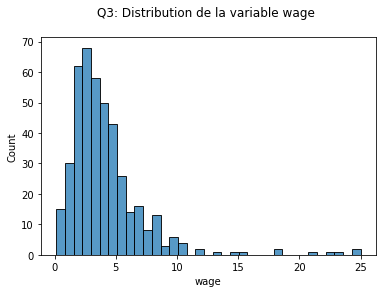

```python
sns.histplot(data=df, x="wage").set(title = "Q3: Distribution de la variable wage \n")
```

```python
# calcul de l'écart-type de la variable "wage"
ecart_type_wage = round(df["wage"].std(), 3)
print("L'écart-type de la variable wage est:", ecart_type_wage)

# calcul de la moyenne de la variable "wage"
moyenne_wage = round(df["wage"].mean(), 3)
print("La moyenne de la variable wage est:", moyenne_wage)
```

```
L'écart-type de la variable wage est: 3.31
La moyenne de la variable wage est: 4.178
```

#### On sélection ne uniquement les observations dont les valeurs de la variable `wage` sont strictement inférieure à 3 fois l'écart type de la moyenne. Cela revient finalement a supprimer les observations qui sont à plus de 3 écart-types de la moyenne

```python
criterion = moyenne_wage + (3 * ecart_type_wage)
print(criterion)
df_temp = df[df.wage < criterion]
```

```
14.108
```

```python
df_temp
```

|  | inlf | hours | kidslt6 | kidsge6 | age | educ | wage | repwage | hushrs | husage | huseduc | huswage | faminc | mtr | motheduc | fatheduc | unem | city | exper | nwifeinc | lwage | expersq |
| --- | --- | --- | --- | --- | --- | --- | --- | --- | --- | --- | --- | --- | --- | --- | --- | --- | --- | --- | --- | --- | --- | --- |
| 0 | 1 | 1610 | 1 | 0 | 32 | 12 | 3.3540 | 2.65 | 2708 | 34 | 12 | 4.0288 | 16310 | 0.7215 | 12 | 7 | 5.0 | 0 | 14 | 10.910060 | 1.210154 | 196 |
| 1 | 1 | 1656 | 0 | 2 | 30 | 12 | 1.3889 | 2.65 | 2310 | 30 | 9 | 8.4416 | 21800 | 0.6615 | 7 | 7 | 11.0 | 1 | 5 | 19.499980 | 0.328512 | 25 |
| 2 | 1 | 1980 | 1 | 3 | 35 | 12 | 4.5455 | 4.04 | 3072 | 40 | 12 | 3.5807 | 21040 | 0.6915 | 12 | 7 | 5.0 | 0 | 15 | 12.039910 | 1.514138 | 225 |
| 3 | 1 | 456 | 0 | 3 | 34 | 12 | 1.0965 | 3.25 | 1920 | 53 | 10 | 3.5417 | 7300 | 0.7815 | 7 | 7 | 5.0 | 0 | 6 | 6.799996 | 0.092123 | 36 |
| 4 | 1 | 1568 | 1 | 2 | 31 | 14 | 4.5918 | 3.60 | 2000 | 32 | 12 | 10.0000 | 27300 | 0.6215 | 12 | 14 | 9.5 | 1 | 7 | 20.100060 | 1.524272 | 49 |
| ... | ... | ... | ... | ... | ... | ... | ... | ... | ... | ... | ... | ... | ... | ... | ... | ... | ... | ... | ... | ... | ... | ... |
| 423 | 1 | 680 | 0 | 5 | 36 | 10 | 2.3118 | 0.00 | 3430 | 43 | 12 | 5.3061 | 19772 | 0.7215 | 7 | 7 | 7.5 | 0 | 2 | 18.199980 | 0.838027 | 4 |
| 424 | 1 | 2450 | 0 | 1 | 40 | 12 | 5.3061 | 6.50 | 2008 | 40 | 8 | 7.2709 | 35641 | 0.6215 | 7 | 7 | 5.0 | 1 | 21 | 22.641060 | 1.668857 | 441 |
| 425 | 1 | 2144 | 0 | 2 | 43 | 13 | 5.8675 | 0.00 | 2140 | 43 | 11 | 8.1776 | 34220 | 0.5815 | 7 | 7 | 7.5 | 1 | 22 | 21.640080 | 1.769429 | 484 |
| 426 | 1 | 1760 | 0 | 1 | 33 | 12 | 3.4091 | 3.21 | 3380 | 34 | 12 | 7.1006 | 30000 | 0.5815 | 12 | 16 | 11.0 | 1 | 14 | 23.999980 | 1.226448 | 196 |
| 427 | 1 | 490 | 0 | 1 | 30 | 12 | 4.0816 | 2.46 | 2430 | 33 | 11 | 6.5844 | 18000 | 0.6915 | 12 | 12 | 7.5 | 1 | 7 | 16.000020 | 1.406489 | 49 |

419 rows × 22 columns

```
[Text(0.5, 1.0, 'Q3: Distribution de la variable wage dont les observations sont inférieures à 3 écart-types de la moyenne \n')]
```

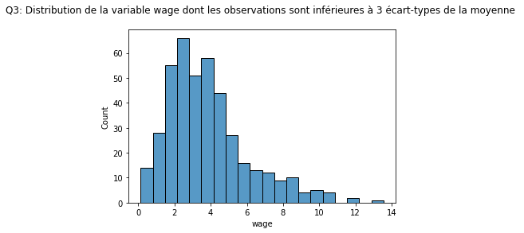

```python
sns.histplot(data=df_temp, x="wage").set(title = "Q3: Distribution de la variable wage dont les observations sont inférieures à 3 écart-types de la moyenne \n")
```

## Question 4

*Calculer les corrélations `motheduc` et `fatheduc`. Expliquer le problème de multi-collinéarité. Commenter.*

```python
correlation = df['motheduc'].corr(df['fatheduc'])
print("Le coefficient de corrélation entre la variable mothereduc et fathereduc est :")
print(correlation)
```

```
Le coefficient de corrélation entre la variable mothereduc et fathereduc est :
0.554063218431167
```

### Commentaires

On en déduit que la corrélation entre l'éducation de la mère et celle du mère est de 55%. Ainsi, dans notre cas, on peut conlcure les variables `fatheduc` et `motheduc` ne sont pas fortement corrélées.

**Explication du problème de multi-colinéarité**

Le problème de multi-colinéartié apparait lorsque lae coefficient de corrélation tend vers **1**. Cela signifie alors qu'il existe une combinaion linéaire entre ces variables fortement corrélées. On dit alors que ces variables sont linéairement dépendantes. Cela pose problème car le déterminant de la matrice $X^{T}X$ devient alors nul. Par conséquent, la matrice $X^{T}X$ n'est pas inversible ce qui amène à estimer l'estimateur des moindre carrés ordinaires (MCO) avec une mauvaise précision. De ce fait, cela augmente la variance des coefficients de régression et les rends instables et difficiles à interpréter. Par ailleurs, cela se répercute également sur les intervalles de confiances qui risquent d'être beaucoup trop large.

Les conséquences de coefficients instables sont les suivantes :

- Les coefficients peuvent sembler non significatifs
- Les coefficients de prédicteurs fortement corrélés vont évoluer en fonction de l'échantillon.

Toutefois, il est nécéssaire de rappeler que la multi-colinéarité n'a aucune influence négative sur le bon ajustement de la droite de regression et sur la qualité des prédictions. Cependant les coefficients individuels associés à chaque variables explicative ne peuvent pas être interprétés de façon fiable.

## Question 5

*Faites un graphique en nuage de point entre `wage` et `educ`. S'agit-il d'un effet "toute chose étant égale par ailleurs ?"*

```
[Text(0.5, 1.0, 'Nuage de points entre wage et educ \n')]
```

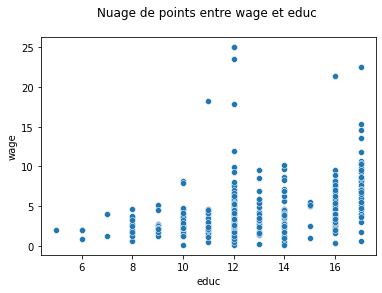

```python
sns.scatterplot(data = df, x="educ", y="wage").set(title = "Nuage de points entre wage et educ \n")
```

### Commentaires

Au regard du nuage de points, le graphique semble mettre en évidence une corrélation entre les variables `wage` et `educ`.

**Sagit-il d'un effet ceteris-paribus ?**

Un effet ceteris paribus fait référence à l'effet direct que possède une variable $X$ sur une autre variable $Y$ tout en faisant l'hypothèse que le reste des variables du modèle restent constantes et inchangées au cours du temps. Autrement dit, une approche *ceteris paribus* permet de simplifier le travail d'analyse en supposant qu'une seule variable possède une influence sur une autre variable du modèle économique. Cette technique permet d'isoler les effets d'autres évènement qui pourraient éventuellement se produire au même moment.

Sur la base de ce qui a été évoqué précédemment, L'effet observé dans notre cas ne semble pas être un effet *ceteris paribus* car d'autres variables différentes de celle de `educ` peuvent avoir une influence direct sur la variable `wage`. Par exemple, l'expérience profesionnelle peut être une variable interessante à prendre en compte pour le calcul du salaire car on sait intuitivement que les années d'expérience ont un influence importante sur le salaire d'un employé. Une personne disposant d'une expérience profesionnelle de 20 ans dans un domaine d'activité précis possèdera un salaire plus élevé qu'une personne ne disposant que de 2 ans d'expertise dans ce même domaine.

## Question 6

**Quelle est l'hypothèse fondamentale qui garantit des estimateurs non biaisés ?**

L'hypothèse fondamentale qui garantit des estimateurs non biaisés fait référence au résidus (variable $u$ non observée) du modèle qui doivent être de moyenne nulle et non corrélée avec les regresseurs $X$. On peut alors écrire la chose suivante : $E(u | X) = E(u) = 0$

**Expliquer le biais de variable omise.**

Si l'on omet une variable déterminante pour la prédiction du modèle, cela aboutit à un estimateur MCO biaisée. Autrement dit, si l'on oubli de prendre en compte une variable essentielle dans la qualité de la prédiction du modèle alors, cette variable va se retrouver dans le terme d'erreur. De plus, si cette variable explicative est corrélée avec d'autres variables explicatives du prisent en compte par le modèle alors $E(u | X) \ne 0$ car le résidu $u$ intègrera une variable explicative. Par conséquent, l'estimateur des MCO se retrouvera biaisé.

### A noter que pour les questions suivantes nous travaillerons exclusivement avec le dataframe dont les observations où le salaire > 0 (`wage` > 0)

#### La dataframe contient 428 lignes et 22 colonnes

```python
df # dataframe dont les observations où le salaire > 0
```

|  | inlf | hours | kidslt6 | kidsge6 | age | educ | wage | repwage | hushrs | husage | huseduc | huswage | faminc | mtr | motheduc | fatheduc | unem | city | exper | nwifeinc | lwage | expersq |
| --- | --- | --- | --- | --- | --- | --- | --- | --- | --- | --- | --- | --- | --- | --- | --- | --- | --- | --- | --- | --- | --- | --- |
| 0 | 1 | 1610 | 1 | 0 | 32 | 12 | 3.3540 | 2.65 | 2708 | 34 | 12 | 4.0288 | 16310 | 0.7215 | 12 | 7 | 5.0 | 0 | 14 | 10.910060 | 1.210154 | 196 |
| 1 | 1 | 1656 | 0 | 2 | 30 | 12 | 1.3889 | 2.65 | 2310 | 30 | 9 | 8.4416 | 21800 | 0.6615 | 7 | 7 | 11.0 | 1 | 5 | 19.499980 | 0.328512 | 25 |
| 2 | 1 | 1980 | 1 | 3 | 35 | 12 | 4.5455 | 4.04 | 3072 | 40 | 12 | 3.5807 | 21040 | 0.6915 | 12 | 7 | 5.0 | 0 | 15 | 12.039910 | 1.514138 | 225 |
| 3 | 1 | 456 | 0 | 3 | 34 | 12 | 1.0965 | 3.25 | 1920 | 53 | 10 | 3.5417 | 7300 | 0.7815 | 7 | 7 | 5.0 | 0 | 6 | 6.799996 | 0.092123 | 36 |
| 4 | 1 | 1568 | 1 | 2 | 31 | 14 | 4.5918 | 3.60 | 2000 | 32 | 12 | 10.0000 | 27300 | 0.6215 | 12 | 14 | 9.5 | 1 | 7 | 20.100060 | 1.524272 | 49 |
| ... | ... | ... | ... | ... | ... | ... | ... | ... | ... | ... | ... | ... | ... | ... | ... | ... | ... | ... | ... | ... | ... | ... |
| 423 | 1 | 680 | 0 | 5 | 36 | 10 | 2.3118 | 0.00 | 3430 | 43 | 12 | 5.3061 | 19772 | 0.7215 | 7 | 7 | 7.5 | 0 | 2 | 18.199980 | 0.838027 | 4 |
| 424 | 1 | 2450 | 0 | 1 | 40 | 12 | 5.3061 | 6.50 | 2008 | 40 | 8 | 7.2709 | 35641 | 0.6215 | 7 | 7 | 5.0 | 1 | 21 | 22.641060 | 1.668857 | 441 |
| 425 | 1 | 2144 | 0 | 2 | 43 | 13 | 5.8675 | 0.00 | 2140 | 43 | 11 | 8.1776 | 34220 | 0.5815 | 7 | 7 | 7.5 | 1 | 22 | 21.640080 | 1.769429 | 484 |
| 426 | 1 | 1760 | 0 | 1 | 33 | 12 | 3.4091 | 3.21 | 3380 | 34 | 12 | 7.1006 | 30000 | 0.5815 | 12 | 16 | 11.0 | 1 | 14 | 23.999980 | 1.226448 | 196 |
| 427 | 1 | 490 | 0 | 1 | 30 | 12 | 4.0816 | 2.46 | 2430 | 33 | 11 | 6.5844 | 18000 | 0.6915 | 12 | 12 | 7.5 | 1 | 7 | 16.000020 | 1.406489 | 49 |

428 rows × 22 columns

## Question 7

*Faire la régression du log de wage en utilisant comme variables explicatives une `constante`, `city`, `educ`, `exper`, `nwifeinc`, `kidslt6`, `kidsgt6`.*

*Commentez l'histogramme des résidus.*

```python
lwage = df["lwage"]
y = lwage

constante = np.ones(np.shape(lwage))
city = df["city"]
educ = df["educ"]
exper = df["exper"]
nwifeinc = df["nwifeinc"]
kidslt6 = df["kidslt6"]
kidsge6 = df["kidsge6"]

X = np.column_stack((constante,
                     city,
                     educ,
                     exper,
                     nwifeinc,
                     kidslt6,
                     kidsge6))
```

### Calcul des estimateurs :

$\beta = (X^{T}X)^{-1}X^{T}Y$

```python
beta = np.linalg.inv(X.T @ X)@X.T@y

beta_estimateur_dict = {
    "constante" : beta[0],
    "city" : beta[1],
    "educ" : beta[2],
    "exper" : beta[3],
    "nwifeinc" : beta[4],
    "kidslt6" : beta[5],
    "kidsge6" : beta[6],
}

print("Les estimateurs 𝛽 de chaque variables explicatives du modèle sont :\n")
beta_estimateur_dict
```

```
Les estimateurs 𝛽 de chaque variables explicatives du modèle sont :
```

```
{'constante': -0.39897522667501173,
 'city': 0.03526789293230923,
 'educ': 0.1022475478401905,
 'exper': 0.015487872095843404,
 'nwifeinc': 0.004882695681563886,
 'kidslt6': -0.0453028703816894,
 'kidsge6': -0.011703506704368392}
```

### Calcul des résidus :

On sait que = $Y = X\beta + u$

avec $u = résidus$

donc :

$u = Y - X\beta$

```python
u = y - X @ beta
df_u = pd.DataFrame(u)
print("Les résidus u sont : \n")
df_u = df_u.rename(columns={"lwage": "residus"})
df_u
```

```
Les résidus u sont :
```

|  | residus |
| --- | --- |
| 0 | 0.157361 |
| 1 | -0.683996 |
| 2 | 0.475451 |
| 3 | -0.826891 |
| 4 | 0.318666 |
| ... | ... |
| 423 | 0.153203 |
| 424 | 0.381503 |
| 425 | 0.380930 |
| 426 | 0.040873 |
| 427 | 0.368391 |

428 rows × 1 columns

```
[Text(0.5, 1.0, 'Distribution des résidus \n')]
```

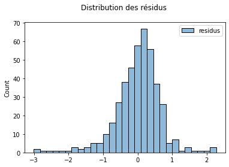

```python
sns.histplot(data = df_u).set(title = "Distribution des résidus \n")
```

### Commentaires

On remarque que l'histogramme des résidus semble suivre la distribution d'une loi normale car la moyenne des résidus est proche de 0. Cela signifie que le distribution est centrée en 0. A l'inverse, la distribution n'est pas symétrique et semble être légèrement asymétrique négativement. Par conséquent, des tests supplémentaires doivent être réalisés pour vérifier la pertinence de ces hypothèses.

## Question 8

### Test d'hypothèse de non significativité

*Tester l'hypothèse de non significativité de `nwifeinc` avec un seuil de significativité de **1%**, **5%** et **10%** (test alternatif des deux côtés). Commentez les p-values.*

$X^{T}Y = (X^{T}X)\beta$

$\hat{\beta} = (X^{T}X)^{-1}X^{T}Y$

$Var(\hat{\beta}) = Var((X^{T}X)^{-1}X^{T}(X\beta+u)) = ((X^{T}X)^{-1}X^{T}Var(u)X(X^{T}X)^{-1}) = \sigma^{2}(X^{T}X)^{-1}$

$(X^{T}X)^{-1}$ est la matrice de covariance. On prendra la diagonale pour obtenir les coefficients par écart-type $std = diag(\sqrt{\sigma^{2}(X^{T}X)^{-1}})$

On note : Tester l'hypothèse de non significativité de la variable `nwifeinc` revient à faire l'hypothèse :

$H_{0} : \beta_{nwifeinc} = 0$

$H_{0}$ signifiant que la variable `nwifeinc` n'a pas une importance sur l'augmentation du salaire d'une personne.

On peut également poser $H_{1}: \beta_{nwifeinc} \ne 0$

#### Calcul de la statistique de Student pour toutes les variables du modèle

```python
n,k = X.shape
sig2 = u.T @ u / (n-k)
Var = sig2 * np.linalg.inv(X.T @ X)
std = np.sqrt(Var.diagonal())

stat_student = beta / std


stat_student_dict = {
    "constante" : stat_student[0],
    "city" : stat_student[1],
    "educ" : stat_student[2],
    "exper" : stat_student[3],
    "nwifeinc" : stat_student[4],
    "kidslt6" : stat_student[5],
    "kidsge6" : stat_student[6],
}

print("Les statististiques de student associées à chaque variable pour le test d'hypothèse bilatérale sont : \n")
stat_student_dict
```

```
Les statististiques de student associées à chaque variable pour le test d'hypothèse bilatérale sont :
```

```
{'constante': -1.9269466911402628,
 'city': 0.5025468652951948,
 'educ': 6.770561785365637,
 'exper': 3.45171828081279,
 'nwifeinc': 1.4659514850330864,
 'kidslt6': -0.5310523188883772,
 'kidsge6': -0.4343577482482585}
```

#### Calcul de la p-valeur pour la variable `nwifeinc`

```python
# calcul de la p-valeur pour la variable nwifeinc
stat_student_nwifeinc = beta[4] / std[4] # nwifeinc se trouve à la 4ème position de X
p_value = t.sf(stat_student_nwifeinc, n-k)*2 # on multiple par 2 car on effectue un test d'hypothèse bilatérale

print("La p-valeur pour la variable nwifeinc est (Test d'hypothèse bilatérale): \n", p_value)
```

```
La p-valeur pour la variable nwifeinc est (Test d'hypothèse bilatérale):
 0.14340798202513313
```

#### Calcul des region de rejets

- alpha = 1%
- alhpa = 5%
- alpha = 10%

```python
# Calcul des quantiles pour chaque risque
quantile_1_percent = 1 - ((1 / 100) / 2)
quantile_5_percent = 1 - ((5 / 100) / 2)
qualtile_10_percent = 1 - ((10 / 100) / 2)

seuil_critique_1 = t.ppf(quantile_1_percent, n-k)
seuil_critique_5= t.ppf(quantile_5_percent, n-k)
seuil_critique_10 = t.ppf(qualtile_10_percent, n-k)

print("Pour un risque alpha = 1% le seuil critique est :", seuil_critique_1)
print("\n\n Pour un risque alpha = 5% le seuil critique est :", seuil_critique_5)
print("\n\n Pour un risque alpha = 10% le seuil critique est :", seuil_critique_10)
```

```
Pour un risque alpha = 1% le seuil critique est : 2.5875575730543354


 Pour un risque alpha = 5% le seuil critique est : 1.965614792008086


 Pour un risque alpha = 10% le seuil critique est : 1.6484810571255268
```

#### Test de significativité pour la variable `nwifeinc`

```python
alpha = [1, 5, 10]

for risque_alpha in alpha:
    print(f"Pour un risque alpha = {risque_alpha}%")
    if p_value > (risque_alpha / 100):
        print(f"On ne peut pas rejeter l'hypothèse H0 car {round(p_value, 3)} > {risque_alpha / 100}")
        print("La variable nwifeinc n'est pas significative pour le salaire \n\n")
    else:
        print(f"On rejette l'hypothèse H0 car {round(p_value, 3)} > {risque_alpha / 100}")
        print("La variable nwifeinc est significative pour le salaire \n\n")
```

```
Pour un risque alpha = 1%
On ne peut pas rejeter l'hypothèse H0 car 0.143 > 0.01
La variable nwifeinc n'est pas significative pour le salaire


Pour un risque alpha = 5%
On ne peut pas rejeter l'hypothèse H0 car 0.143 > 0.05
La variable nwifeinc n'est pas significative pour le salaire


Pour un risque alpha = 10%
On ne peut pas rejeter l'hypothèse H0 car 0.143 > 0.1
La variable nwifeinc n'est pas significative pour le salaire
```

### Commentaires

Précédemment nous avons posé:

$H_{0} : \beta_{nwifeinc} = 0$

$H_{1} : \beta_{nwifeinc} \ne 0$

On a pu remarquer le $p-valeur_{nwifeinc} = 0.143 > \alpha = \{0.01, 0.05, 0.1\}$ donc on ne peut pas rejeter l'hypothèse nulle $H_{0}$ et on rejette l'hypothèse non nulle $H_{1}$ pour les seuils **𝛼 = {1%, 5%, 10%}**. Ne pas rejeter l'hypothèse $H_{0}$ et rejeter l'hypothèse $H_{1}$ signifie que la variable `nwifeinc` (non wife income) n'est pas significative pour le salaire d'une personne. Cela semble intuitif car le salaire d'une personne dépend fortement de l'année d'expérience et des nombre d'année d'étude.

#### On élargit l'étude des tests de significativité à toutes les variables du modèle

```python
list_p_valeur = list()
for t_student in stat_student:
    t_stat_var = t.sf(t_student, n-k)*2
    list_p_valeur.append(t_stat_var)

p_valeur_dict = {
    "constante" : list_p_valeur[0],
    "city" : list_p_valeur[1],
    "educ" : list_p_valeur[2],
    "exper" : list_p_valeur[3],
    "nwifeinc" : list_p_valeur[4],
    "kidslt6" : list_p_valeur[5],
    "kidsge6" : list_p_valeur[6],
}
print("Les p-valeur associés à chaque variable pour le test d'hypothèse bilatérale sont : \n")
p_valeur_dict
```

```
Les p-valeur associés à chaque variable pour le test d'hypothèse bilatérale sont :
```

[output not shown]

### Commentaires

Cela confirme l'hypothèse que nous avions émis précédemment à savoir que le nombre des années d'étude et le nombre des années d'expérience sont des facteurs déterminants pour le salaire d'une personne.

## Question 9

### Test d'égalité à une valeur

*Tester l’hypothèse que le coefficient associé à `nwifeinc` est égal à **0.01** avec un seuil de significativité de **5%** (test à alternatif des deux côtés)*

Pour ce test on pose :

$H_{0}: \beta_{nwifeinc} = 0.01$

$H_{1}: \beta_{nwifeinc} \ne 0.01$

```python
# calcul de la p-valeur pour la variable nwifeinc
stat_student_nwifeinc_bis = (0.01 - beta[4]) / std[4] # nwifeinc se trouve à la 4ème position de X
p_value_bis = t.sf(stat_student_nwifeinc_bis, n-k)*2 # on multiple par 2 car on effectue un test d'hypothèse bilatérale

print("La p-valeur pour la variable nwifeinc est (Test d'hypothèse bilatérale): \n", p_value_bis)
```

```
La p-valeur pour la variable nwifeinc est (Test d'hypothèse bilatérale):
 0.12519418591700024
```

```python
risque_alpha = 5
print(f"Pour un risque alpha = {risque_alpha}%")
if p_value > (risque_alpha / 100):
    print(f'Statistique de student = {stat_student_nwifeinc_bis}')
    print(f'p-valeur(nwifeinc) = {p_value_bis}')
    print(f'Seuil critique = {t.ppf(quantile_5_percent, n-k)}')
    print(f"On ne rejette pas l'hypothèse H0 car {round(p_value_bis, 3)} > {risque_alpha / 100}")
    print("La variable nwifeinc n'est pas significative pour le salaire \n\n")
else:
    print(f'Statistique de student(nwifeinc) = {stat_student_nwifeinc_bis}')
    print(f'p-valeur(nwifeinc) = {p_value_bis}')
    print(f'Seuil critique = {t.ppf(quantile_5_percent, n-k)}')
    print(f"On rejette l'hypothèse H0 car {round(p_value_bis, 3)} < {risque_alpha / 100}")
    print("La variable nwifeinc est significative pour le salaire \n\n")
```

```
Pour un risque alpha = 5%
Statistique de student = 1.536388985556214
p-valeur(nwifeinc) = 0.12519418591700024
Seuil critique = 1.965614792008086
On ne rejette pas l'hypothèse H0 car 0.125 > 0.05
La variable nwifeinc n'est pas significative pour le salaire
```

### Commentaires

Pour ce nouveau test d'hypothèse d'égalité à une valeur, on a posé :

$H_{0}: \beta_{nwifeinc} = 0.01$

$H_{1}: \beta_{nwifeinc} \ne 0.01$

On remarque que $p-valeur_{nwifeinc} = 0.125 > \alpha = 0.05$. Donc on ne peut pas rejeter l'hypothèse $H_{0}: \beta_{nwifeinc} = 0.01$ à un seuil de **5%**.

## Question 10

*Tester l’hypothèse jointe que le coefficient de `nwifeinc` est égal à **0.01** et que celui de `city` est égal à **0.05**.*

Pour tester une hypothèse jointe, il est nécessaire de réaliser un Test de Fisher :

\begin{equation} F=\frac{\left(S S R_{r}-S S R_{u r}\right) / q}{S S R_{u r} /(n-k-1)} \sim F(q, n-k-1) \end{equation}

Pour ce faire on pose les hypothèses jointes suivantes :

$H_{0}: \beta_{nwifeinc} = 0.01$ et $\beta_{city} = 0.05$

$H_{1}: \beta_{nwifeinc} \ne 0.01$ et $\beta_{city} \ne 0.05$

On pose:

$\begin{cases} \beta_{nwifeinc} = 0.01 \\ \beta_{city} = 0.05 \end{cases}$

$lwage = constante + \beta_{city} X_{city} + \beta_{educ} X_{educ} + \beta_{exper} X_{exper} + \beta_{nwifeinc} X_{nwifeinc} + \beta_{kidslt6} X_{kidslt6} + \beta_{kidsge6} X_{kidsge6}$

$lwage = constante + 0.05 X_{city} + \beta_{educ} X_{educ} + \beta_{exper} X_{exper} + 0.01 X_{nwifeinc} + \beta_{kidslt6} X_{kidslt6} + \beta_{kidsge6} X_{kidsge6}$

$lwage - 0.01 X_{nwifeinc} - 0.05 X_{city} = constante + \beta_{educ} X_{educ} + \beta_{exper} X_{exper} + \beta_{kidslt6} X_{kidslt6} + \beta_{kidsge6} X_{kidsge6}$

Pour réaliser un test de fisher, il faut établir le modèle non contraint (i.e le modèle complet) et le modèle contraint.

**Modèle complet** :

$(constante,city,educ,exper,nwifeinc,kidslt6,kidsge6)$

**Modèle contraint** :

$(constante,educ,exper,kidslt6,kidsge6)$

avec

$X = constante + \beta_{educ} X_{educ} + \beta_{exper} X_{exper} + \beta_{kidslt6} X_{kidslt6} + \beta_{kidsge6} X_{kidsge6}$

$Y = lwage - 0.01 X_{nwifeinc} - 0.05 X_{city}$

#### Modèle non contraint (i.e modèle complet)

$(constante,city,educ,exper,nwifeinc,kidslt6,kidsge6)$

```python
# Etablissement du modèle non contraint
y_complet = lwage
X_complet = np.column_stack((constante,
                     city,
                     educ,
                     exper,
                     nwifeinc,
                     kidslt6,
                     kidsge6))
n,k = np.shape(X_complet)
print("n = ", n)
print("k = ", k)

model_complet = sm.OLS(y_complet, X_complet)
results = model_complet.fit()
print(results.summary())
u = results.resid
SSRO=u.T@u
print("SSRO =", SSRO)
```

```
n =  428
k =  7
                            OLS Regression Results
==============================================================================
Dep. Variable:                  lwage   R-squared:                       0.156
Model:                            OLS   Adj. R-squared:                  0.144
Method:                 Least Squares   F-statistic:                     12.92
Date:                Wed, 04 May 2022   Prob (F-statistic):           2.00e-13
Time:                        12:05:58   Log-Likelihood:                -431.92
No. Observations:                 428   AIC:                             877.8
Df Residuals:                     421   BIC:                             906.3
Df Model:                           6
Covariance Type:            nonrobust
==============================================================================
                 coef    std err          t      P>|t|      [0.025      0.975]
------------------------------------------------------------------------------
const         -0.3990      0.207     -1.927      0.055      -0.806       0.008
x1             0.0353      0.070      0.503      0.616      -0.103       0.173
x2             0.1022      0.015      6.771      0.000       0.073       0.132
x3             0.0155      0.004      3.452      0.001       0.007       0.024
x4             0.0049      0.003      1.466      0.143      -0.002       0.011
x5            -0.0453      0.085     -0.531      0.596      -0.213       0.122
x6            -0.0117      0.027     -0.434      0.664      -0.065       0.041
==============================================================================
Omnibus:                       79.542   Durbin-Watson:                   1.979
Prob(Omnibus):                  0.000   Jarque-Bera (JB):              287.193
Skew:                          -0.795   Prob(JB):                     4.33e-63
Kurtosis:                       6.685   Cond. No.                         178.
==============================================================================

Warnings:
[1] Standard Errors assume that the covariance matrix of the errors is correctly specified.
SSRO = 188.5899801926394
```

**Modèle contraint** :

$(constante,educ,exper,kidslt6,kidsge6)$

avec

$X = constante + \beta_{educ} X_{educ} + \beta_{exper} X_{exper} + \beta_{kidslt6} X_{kidslt6} + \beta_{kidsge6} X_{kidsge6}$

$Y = lwage - 0.01 X_{nwifeinc} - 0.05 X_{city}$

```python
# Etablissement du modèle contraint

X_contraint = np.column_stack((constante,
                     educ,
                     exper,
                     kidslt6,
                     kidsge6))

y_contraint = lwage - 0.01 * nwifeinc - 0.05 * city

model_contraint = sm.OLS(y_contraint, X_contraint)
results = model_contraint.fit()
print(results.summary())
u = results.resid
SSR1 = u.T@u
print("SSR1 =", SSR1)
```

```
                            OLS Regression Results
==============================================================================
Dep. Variable:                      y   R-squared:                       0.130
Model:                            OLS   Adj. R-squared:                  0.122
Method:                 Least Squares   F-statistic:                     15.84
Date:                Wed, 04 May 2022   Prob (F-statistic):           4.34e-12
Time:                        12:05:58   Log-Likelihood:                -433.28
No. Observations:                 428   AIC:                             876.6
Df Residuals:                     423   BIC:                             896.9
Df Model:                           4
Covariance Type:            nonrobust
==============================================================================
                 coef    std err          t      P>|t|      [0.025      0.975]
------------------------------------------------------------------------------
const         -0.4287      0.206     -2.082      0.038      -0.833      -0.024
x1             0.0948      0.014      6.586      0.000       0.067       0.123
x2             0.0167      0.004      3.765      0.000       0.008       0.025
x3            -0.0316      0.085     -0.372      0.710      -0.199       0.135
x4            -0.0114      0.027     -0.422      0.673      -0.064       0.042
==============================================================================
Omnibus:                       76.581   Durbin-Watson:                   1.976
Prob(Omnibus):                  0.000   Jarque-Bera (JB):              263.518
Skew:                          -0.779   Prob(JB):                     6.00e-58
Kurtosis:                       6.514   Cond. No.                         123.
==============================================================================

Warnings:
[1] Standard Errors assume that the covariance matrix of the errors is correctly specified.
SSR1 = 189.7878808521723
```

#### Calcul de Statistique de Fisher

```python
F = ((SSR1 - SSRO)/2)/(SSRO/(n-k)) # on divise par car on a 2 contraintes
print("La statistique de Fisher de l'hypothèse jointe est : \n F-stat = ", F)
```

```
La statistique de Fisher de l'hypothèse jointe est :
 F-stat =  1.3370704454929372
```

#### Calcul de la p-valeur

```python
p_val = stats.f.sf(F,2,n-k)
print("La p-valeur de l'hypothèse jointe est \n p-valeur = ", p_val)
```

```
La p-valeur de l'hypothèse jointe est
 p-valeur =  0.2637267136252519
```

### Commentaires

On a posé les hypothèses jointes suivantes :

$H_{0}: \beta_{nwifeinc} = 0.01$ et $\beta_{city} = 0.05$

$H_{1}: \beta_{nwifeinc} \ne 0.01$ et $\beta_{city} \ne 0.05$

Pour ce test à a un seuil $\alpha = 5%$ on obtient :

- $stat-Fischer = 1.337$
- $p-valeur = 0.264$

On remarque que $p-valeur = 0.264 > \alpha = 0.05$. Donc on ne peut pas rejeter l'hypothèse jointe $H_{0}: \beta_{nwifeinc} = 0.01$ et $\beta_{city} = 0.05$ à un seuil de **5%**.

### Question 11

*Tester l’hypothèse jointe que $\beta*{nwifeinc} + \beta*{city}=0.1$ et $\beta*{educ} + \beta*{exper} = 0.1$*

Pour répondre à cette question on procèdera de la même manière que pour la question 10 à savoir, on réalisera un test de Fisher en établissant le modèle complet et le modèle contraint

Pour ce faire on pose les hypothèses jointes suivantes :

$H_{0}: \beta_{nwifeinc} + \beta_{city}=0.1$ et $\beta_{educ} + \beta_{exper} = 0.1$

$H_{1}: \beta_{nwifeinc} + \beta_{city} \ne 0.1$ et $\beta_{educ} + \beta_{exper} \ne 0.1$

Pour ce test d'hypothèse jointe on pose:

$\begin{cases} \beta_{nwifeinc} + \beta_{city}=0.1 \\ \beta_{educ} + \beta_{exper} = 0.1 \end{cases}$

$\Leftrightarrow$

$\begin{cases} \beta_{nwifeinc} = 0.1 - \beta_{city} \\ \beta_{educ} = 0.1 - \beta_{exper} \end{cases}$

$lwage = constante + \beta_{city} X_{city} + \beta_{educ} X_{educ} + \beta_{exper} X_{exper} + \beta_{nwifeinc} X_{nwifeinc} + \beta_{kidslt6} X_{kidslt6} + \beta_{kidsge6} X_{kidsge6}$

$lwage = constante + \beta_{city} X_{city} + (0.1 - \beta_{exper}) X_{educ} + \beta_{exper} X_{exper} + (0.1 - \beta_{city}) X_{nwifeinc} + \beta_{kidslt6} X_{kidslt6} + \beta_{kidsge6} X_{kidsge6}$

$lwage = constante + \beta_{city} X_{city} + 0.1 X_{educ} - \beta_{exper} X_{educ} + \beta_{exper} X_{exper} + 0.1 X_{nwifeinc} - \beta_{city} X_{nwifeinc} + \beta_{kidslt6} X_{kidslt6} + \beta_{kidsge6} X_{kidsge6}$

$lwage - 0.1 X_{educ} - 0.1 X_{nwifeinc} = constante + \beta_{city} X_{city} - \beta_{exper} X_{educ} + \beta_{exper} X_{exper} - \beta_{city} X_{nwifeinc} + \beta_{kidslt6} X_{kidslt6} + \beta_{kidsge6} X_{kidsge6}$

$lwage - 0.1 X_{educ} - 0.1 X_{nwifeinc} = constante + \beta_{city} (X_{city} - X_{nwifeinc}) - \beta_{exper} (X_{exper} - X_{educ}) + \beta_{kidslt6} X_{kidslt6} + \beta_{kidsge6} X_{kidsge6}$

Pour réaliser un test de fisher, il faut établir le modèle non contraint (i.e le modèle complet) et le modèle contraint.

#### Modèle non contraint (i.e modèle complet)

On résutilisera les valeurs calculés à la **question 10** car le modèle complet (non contraint) reste inchangé.

On rappel :

- n = 428
- k = 7
- SSRO = 188.5899801926394

$(constante,city,educ,exper,nwifeinc,kidslt6,kidsge6)$

#### Modèle contraint

$(constante,kidslt6,kidsge6)$

avec

$X = constante + \beta_{city} (X_{city} - X_{nwifeinc}) - \beta_{exper} (X_{exper} - X_{educ}) + \beta_{kidslt6} X_{kidslt6} + \beta_{kidsge6} X_{kidsge6}$

$Y = lwage - 0.1 X_{educ} - 0.1 X_{nwifeinc}$

```python
# Etablissement du modèle contraint

X_contraint_bis = np.column_stack((constante, city - nwifeinc, exper - educ, kidslt6, kidsge6))

y_contraint_bis = lwage - 0.1 * educ - 0.1 * nwifeinc

model_contraint_bis = sm.OLS(y_contraint_bis, X_contraint_bis)
results = model_contraint_bis.fit()
print(results.summary())
u = results.resid
SSR1 = u.T@u
print("SSR1 =", SSR1)
```

```
                            OLS Regression Results
==============================================================================
Dep. Variable:                      y   R-squared:                       0.705
Model:                            OLS   Adj. R-squared:                  0.702
Method:                 Least Squares   F-statistic:                     252.9
Date:                Wed, 04 May 2022   Prob (F-statistic):          9.73e-111
Time:                        12:05:58   Log-Likelihood:                -432.86
No. Observations:                 428   AIC:                             875.7
Df Residuals:                     423   BIC:                             896.0
Df Model:                           4
Covariance Type:            nonrobust
==============================================================================
                 coef    std err          t      P>|t|      [0.025      0.975]
------------------------------------------------------------------------------
const         -0.2133      0.079     -2.700      0.007      -0.369      -0.058
x1             0.0948      0.003     29.720      0.000       0.089       0.101
x2             0.0141      0.004      3.275      0.001       0.006       0.023
x3            -0.0371      0.085     -0.437      0.662      -0.204       0.130
x4            -0.0159      0.026     -0.606      0.545      -0.068       0.036
==============================================================================
Omnibus:                       78.883   Durbin-Watson:                   1.973
Prob(Omnibus):                  0.000   Jarque-Bera (JB):              272.220
Skew:                          -0.803   Prob(JB):                     7.73e-60
Kurtosis:                       6.562   Cond. No.                         59.4
==============================================================================

Warnings:
[1] Standard Errors assume that the covariance matrix of the errors is correctly specified.
SSR1 = 189.4166475528712
```

#### Calcul de Statistique de Fisher

```python
F = ((SSR1 - SSRO)/2)/(SSRO/(n-k))
print("La statistique de Fisher de l'hypothèse jointe est : \n F-stat = ", F)
```

```
La statistique de Fisher de l'hypothèse jointe est :
 F-stat =  0.9227079781812848
```

#### Calcul de la p-valeur

```python
p_val = stats.f.sf(F,2,n-k)
print("La p-valeur de l'hypothèse jointe est \n p-valeur = ", p_val)
```

```
La p-valeur de l'hypothèse jointe est
 p-valeur =  0.3982435347480464
```

### Commentaires

On a posé les hypothèses jointes suivantes :

$H_{0}: \beta_{nwifeinc} + \beta_{city}=0.1$ et $\beta_{educ} + \beta_{exper} = 0.1$

$H_{1}: \beta_{nwifeinc} + \beta_{city} \ne 0.1$ et $\beta_{educ} + \beta_{exper} \ne 0.1$

Pour ce test à un seuil $\alpha = 5$% on obtient :

- $stat-Fischer = 0.922$
- $p-valeur = 0.398$

On remarque que $p-valeur = 0.398 > \alpha = 0.05$. Donc on ne rejette pas l'hypothèse jointe $H_{0}: \beta_{nwifeinc} + \beta_{city}=0.1$ et $\beta_{educ} + \beta_{exper} = 0.1$ à un seuil de **5%**.

## Question 12

*Faites une représentation graphique de la manière dont le salaire augmente avec l’éducation et l’expérience professionnelle. Commentez*

Pour analyser la manière dont le salaire (`wage`) augmente avec les nombre d'anné d'étude (`educ`) et le nombre d'année d'expérience professionnelle (`exper`), il convient de réaliser la regression linéaire suivante :

De cette façon à l'aide d'un graphique en 3D, avec comme axe $(x,y,z) = (educ, exper, wage)$, il sera possible de visualiser le plan de regression

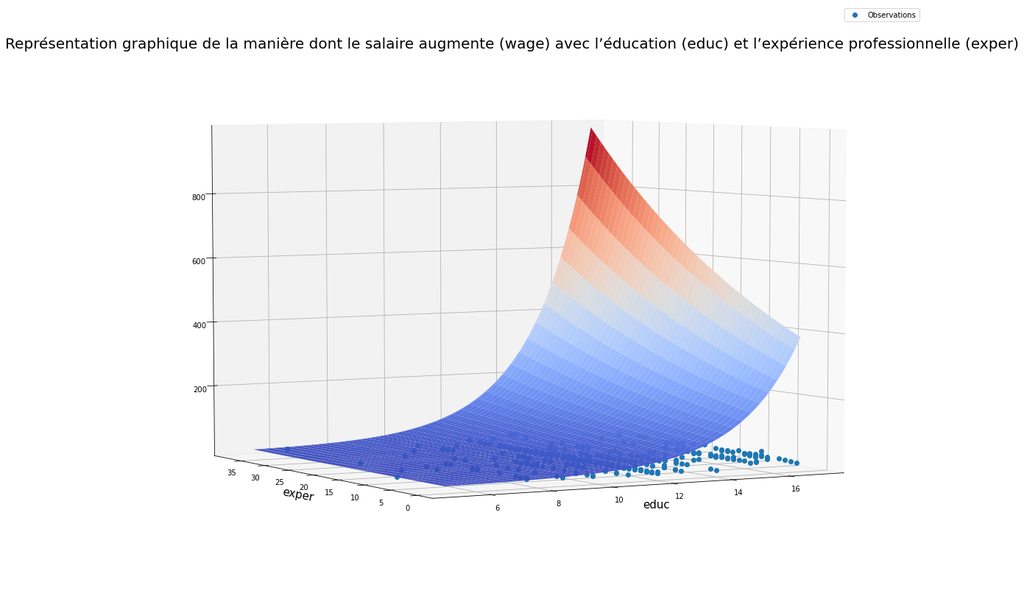

```python
from mpl_toolkits.mplot3d import Axes3D
from matplotlib import cm

# fit regression model
X_exper_educ = df[["educ", "exper"]]
X_exper_educ = sm.add_constant(X_exper_educ)
y_wage = np.exp(df["lwage"])

results_reg = sm.OLS(y_wage, X_exper_educ).fit().params

# On défini notre domaine de définition du plan de regression
XX = np.arange(min(df["educ"]), max(df["educ"]), 0.1)
YY = np.arange(min(df["exper"]), max(df["exper"]), 0.1)

xx, yy = np.meshgrid(XX, YY)

# le plan de regression
zz = np.exp(results_reg[0] + results_reg[1]*xx + results_reg[2]*yy)

fig = plt.figure(figsize=(20,15))
ax = fig.gca(projection='3d')
ax.plot(X_exper_educ['educ'] ,X_exper_educ['exper'], y_wage,'o', label = "Observations")
ax.plot_surface(xx, yy, zz, cmap=cm.coolwarm, linewidth=0)

# 0n trouve le bonne angle de visualisation des données
ax.azim = -120
ax.elev = 5

plt.title("Représentation graphique de la manière dont le salaire augmente (wage) avec l’éducation (educ) et l’expérience professionnelle (exper)", fontsize = 20)
plt.xlabel("educ", size=15)
plt.ylabel("exper", size=15)
plt.legend()
plt.show()
```

## Question 13

### Test d'égalité des coefficients

*Tester l’égalité des coefficients associés aux variables `kidsgt6` et `kidsge6`. Interprétez.*

Tester l’égalité des coefficients associés aux variables `kidsgt6` et `kidsge6` revient à tester l'hypothèse $H_{0}: \beta_{kidsgt6} = \beta_{kidsge6}$

Pour ce test d'hypothèse on pose:

$\beta_{kidsgt6} = \beta_{kidsge6}$

$lwage = constante + \beta_{city} X_{city} + \beta_{educ} X_{educ} + \beta_{exper} X_{exper} + \beta_{nwifeinc} X_{nwifeinc} + \beta_{kidslt6} X_{kidslt6} + \beta_{kidsge6} X_{kidsge6}$

$lwage = constante + \beta_{city} X_{city} + \beta_{educ} X_{educ} + \beta_{exper} X_{exper} + \beta_{nwifeinc} X_{nwifeinc} + \beta_{kidslt6} (X_{kidslt6} + X_{kidsge6})$

Pour cela il est nécssaire d'écrire le modèle en fonction du paramètre $\theta = \beta_{kidsgt6} - \beta_{kidsge6} = 0$

Ce qui revient à faire une regression de $y$ sur : $(constante, city, educ, exper, nwifeinc, kidslt6, kidsge6+kidslt6)$

Pour ce test d'hypothèse on pose alors :

- $H_{0}: \beta_{kidsgt6} = \beta_{kidsgt6}$
- $H_{1}: \beta_{kidsge6} \ne \beta_{kidsge6}$

#### Regression du modèle :

$X = (constante, city, educ, exper, nwifeinc, kidslt6, kidsge6+kidslt6)$

$y = lwage$

```python
X_modif = np.column_stack((constante,
                           city,
                           educ,
                           exper,
                           nwifeinc,
                           kidslt6,
                           kidsge6 + kidslt6))

y = lwage

model = sm.OLS(y, X_modif)
results = model.fit()
print(results.summary())
```

```
                            OLS Regression Results
==============================================================================
Dep. Variable:                  lwage   R-squared:                       0.156
Model:                            OLS   Adj. R-squared:                  0.144
Method:                 Least Squares   F-statistic:                     12.92
Date:                Wed, 04 May 2022   Prob (F-statistic):           2.00e-13
Time:                        12:05:59   Log-Likelihood:                -431.92
No. Observations:                 428   AIC:                             877.8
Df Residuals:                     421   BIC:                             906.3
Df Model:                           6
Covariance Type:            nonrobust
==============================================================================
                 coef    std err          t      P>|t|      [0.025      0.975]
------------------------------------------------------------------------------
const         -0.3990      0.207     -1.927      0.055      -0.806       0.008
x1             0.0353      0.070      0.503      0.616      -0.103       0.173
x2             0.1022      0.015      6.771      0.000       0.073       0.132
x3             0.0155      0.004      3.452      0.001       0.007       0.024
x4             0.0049      0.003      1.466      0.143      -0.002       0.011
x5            -0.0336      0.090     -0.372      0.710      -0.211       0.144
x6            -0.0117      0.027     -0.434      0.664      -0.065       0.041
==============================================================================
Omnibus:                       79.542   Durbin-Watson:                   1.979
Prob(Omnibus):                  0.000   Jarque-Bera (JB):              287.193
Skew:                          -0.795   Prob(JB):                     4.33e-63
Kurtosis:                       6.685   Cond. No.                         178.
==============================================================================

Warnings:
[1] Standard Errors assume that the covariance matrix of the errors is correctly specified.
```

### Commentaires

On a posé pour ce test d'hypothèse, les hypothèses suivantes:

- $H_{0}: \beta_{kidsgt6} = \beta_{kidsgt6}$
- $H_{1}: \beta_{kidsge6} \ne \beta_{kidsge6}$

## Question 14

*Faire le test d'hétéroscédasticité de forme linéaire en donnant la p-valeur. Déterminer la ou les sources d’hétéroscédasticité et corriger avec les méthodes vues en cours. Comparer les écarts-types des coefficients estimés avec ceux obtenus à la question 7. Commenter.*

En régression linéaire, le fait que les résidus du modèle ne soient pas homoscédastiques a pour conséquence que les coefficients du modèle estimés par la méthode des MCO ne soient pas sans biais ce qui conduit à une estimation de leur variance qui n'est pas fiable.

Il convient donc, si l'on soupçonne que les variances ne sont pas homogènes (une simple représentation des résidus en fonction des variables explicatives peut révéler une hétéroscédasticité), d'effectuer un test d'hétéroscédasticité. Plusieurs tests ont été mis au point, avec pour hypothèses nulle et non nulle :

$H_{0}:$ Les résidus sont homoscédastiques

$H_{1}:$ Les résidus sont hétéroscédastiques

Pour tester l'hypothèse d'homoscédasticité du modèle, on peut utiliser la regression des résidus au carré ($u^{2})$ en fonction des variables du modèle.

Pour ce faire, on doit tester la significativité globale de la régression suivante :

$u^{2} = constante, \beta_{city} city + \beta_{educ} educ + \beta_{exper} exper + \beta_{nwifeinc} nwifeinc + \beta_{kidslt6} kidslt6 + \beta_{kidsge6} kidsge6$

Ceci revient donc à tester :

$H_{0}:\beta_{city} = \beta_{educ} = \beta_{exper} = \beta_{nwifeinc} = \beta_{kidslt6} = \beta_{kidsge6} = \beta_{educ} = 0$

Il convient alors de faire un test de Fischer

#### Regression du modèle :

$y = lwage$

```python
y = lwage
X = np.column_stack((constante,
                           city,
                           educ,
                           exper,
                           nwifeinc,
                           kidslt6,
                           kidsge6))

model = sm.OLS(y, X)
results = model.fit()

print("----- Rapport de Regression pour y = lwage -----\n")
print(results.summary())

u = results.resid
u2 = u**2
y = u2
model = sm.OLS(y, X)
results = model.fit()

print("\n\n\n")
print("----- Rapport de Regression pour y = u^2 -----\n")
print(results.summary())
```

```
----- Rapport de Regression pour y = lwage -----

                            OLS Regression Results
==============================================================================
Dep. Variable:                  lwage   R-squared:                       0.156
Model:                            OLS   Adj. R-squared:                  0.144
Method:                 Least Squares   F-statistic:                     12.92
Date:                Wed, 04 May 2022   Prob (F-statistic):           2.00e-13
Time:                        12:05:59   Log-Likelihood:                -431.92
No. Observations:                 428   AIC:                             877.8
Df Residuals:                     421   BIC:                             906.3
Df Model:                           6
Covariance Type:            nonrobust
==============================================================================
                 coef    std err          t      P>|t|      [0.025      0.975]
------------------------------------------------------------------------------
const         -0.3990      0.207     -1.927      0.055      -0.806       0.008
x1             0.0353      0.070      0.503      0.616      -0.103       0.173
x2             0.1022      0.015      6.771      0.000       0.073       0.132
x3             0.0155      0.004      3.452      0.001       0.007       0.024
x4             0.0049      0.003      1.466      0.143      -0.002       0.011
x5            -0.0453      0.085     -0.531      0.596      -0.213       0.122
x6            -0.0117      0.027     -0.434      0.664      -0.065       0.041
==============================================================================
Omnibus:                       79.542   Durbin-Watson:                   1.979
Prob(Omnibus):                  0.000   Jarque-Bera (JB):              287.193
Skew:                          -0.795   Prob(JB):                     4.33e-63
Kurtosis:                       6.685   Cond. No.                         178.
==============================================================================

Warnings:
[1] Standard Errors assume that the covariance matrix of the errors is correctly specified.




----- Rapport de Regression pour y = u^2 -----

                            OLS Regression Results
==============================================================================
```

[output cut: 13 more lines]

```
x1             0.0967      0.110      0.883      0.378      -0.119       0.312
x2             0.0126      0.024      0.536      0.593      -0.034       0.059
x3            -0.0170      0.007     -2.423      0.016      -0.031      -0.003
x4            -0.0036      0.005     -0.683      0.495      -0.014       0.007
x5             0.1279      0.133      0.960      0.337      -0.134       0.390
x6             0.0278      0.042      0.661      0.509      -0.055       0.110
==============================================================================
Omnibus:                      454.545   Durbin-Watson:                   1.642
Prob(Omnibus):                  0.000   Jarque-Bera (JB):            16789.400
Skew:                           4.875   Prob(JB):                         0.00
Kurtosis:                      32.093   Cond. No.                         178.
==============================================================================

Warnings:
[1] Standard Errors assume that the covariance matrix of the errors is correctly specified.
```

### Commentaires

On obtient les résultats suivant :

- statistique de Fisher (F-stat) = 2.009
- p-valeur = 0.0633

Pour le test d'hypothèse d'hétéroscédasticité de forme linéaire, on posé les hyspothèses suivantes:

$H_{0}:$ Les résidus sont homoscédastiques

Autrement dit : $H_{0}:\beta_{city} = \beta_{educ} = \beta_{exper} = \beta_{nwifeinc} = \beta_{kidslt6} = \beta_{kidsge6} = \beta_{educ} = 0$

$H_{1}:$ Les résidus sont hétéroscédastiques

Autrement dit : $H_{1}:\beta_{city} = \beta_{educ} = \beta_{exper} = \beta_{nwifeinc} = \beta_{kidslt6} = \beta_{kidsge6} = \beta_{educ} \ne 0$

L'objectif sera alors de rendre ce modèle clairement homoscédastique en utilisant les méthodes adéquates de façon à faire augmenter la p-value et ainsi pouvoir ne pas rejeter largement l'hypothèse $H_{0}:$ modèle homoscédastique.

### Analysons les sources potentielles d'hétéroscédasticité du modèle.

Pour accomplir cela, il convient d'afficher le nuage de points entre les variables explicatives (i.e `city`, `educ`, `exper`,...) avec la variable cible du modèle `lwage`

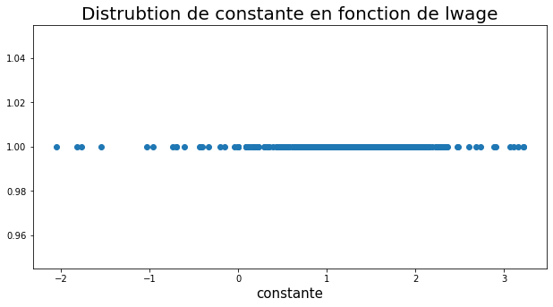

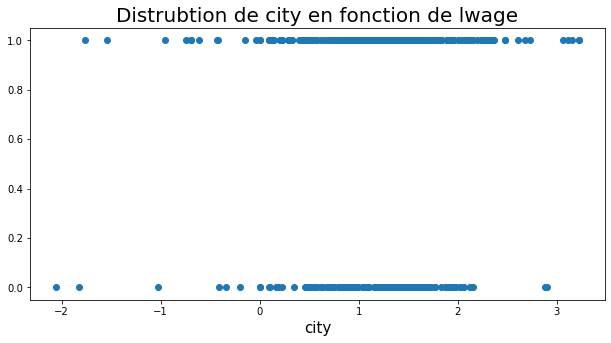

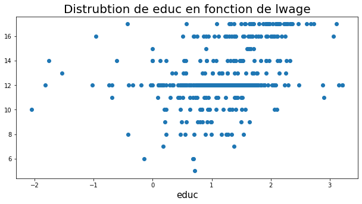

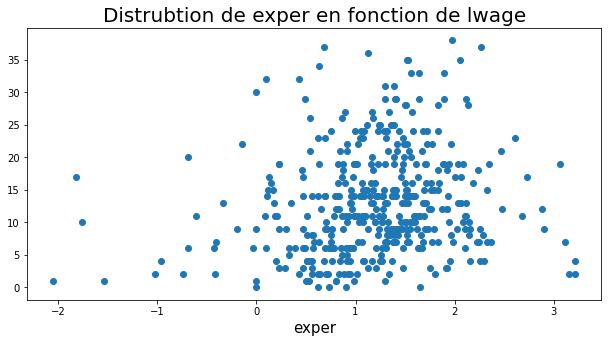

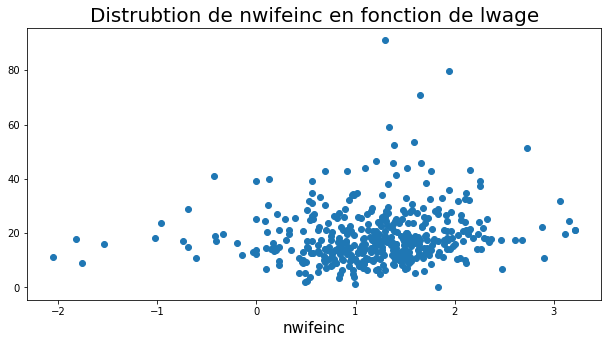

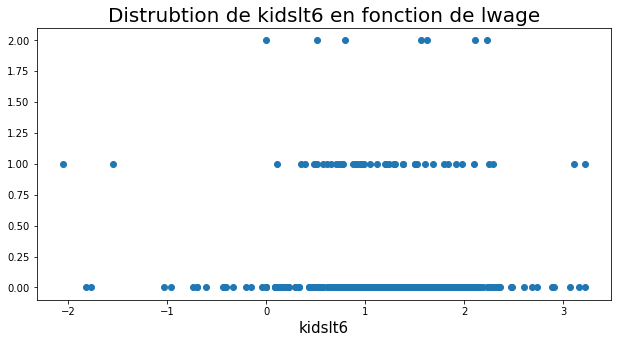

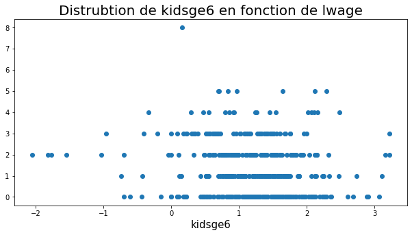

```python
var_explicative = [constante, city, educ, exper, nwifeinc, kidslt6, kidsge6]

var_explicative_str = ["constante", "city", "educ", "exper", "nwifeinc", "kidslt6", "kidsge6"]

var_target = lwage

i = 1
for k in range(len(var_explicative)):
    if i > 3:
        i = 1
        plt.figure(figsize=(35,5))
        plt.subplot(1,3,3)
        plt.scatter(var_target, var_explicative[k])
        plt.xlabel(var_explicative_str[k], fontsize = 15)
        plt.title("Distrubtion de " + var_explicative_str[k] + " en fonction de lwage", fontsize = 20)
        plt.show()
    else:
        plt.figure(figsize=(35,5))
        plt.subplot(1,3,3)
        plt.scatter(var_target, var_explicative[k])
        plt.xlabel(var_explicative_str[k], fontsize = 15)
        plt.title("Distrubtion de " + var_explicative_str[k] + " en fonction de lwage", fontsize = 20)
        plt.show()
    i = i + 1
```

### Commentaires

Au regard des différents graphique qui ont été tracé, on remarque que 2 phénomènes bien distincts se produisent. Par conséquent il est possible de ranger les graphiques associés à chaque variable explicative dans deux catégories:

- **Catégorie 1:** `educ`, `exper` et `nwifeinc`
- **Catégorie 2:** `city`, `kidslt6`, `kidsge6`

Concernant les variables de la **catégorie 1**, d'abord, on remarque que ces dernières sont des variables continues. De plus, on constate qu'ils semblent affecter non linéairement la variable cible `lwage`.

Par ailleurs, concernant les variables de la **catégorie 2**, on constate que ces dernières sont des variables discrètes car elles prennent uniquement un certains nombre de valeurs entières. Par exemple, la variables `city` est présente sous une forme binaire. Les varaibles `kidslt6` (kids < 6 years) et `kidsge6` (kids 6-18) sont présentes sous un forme continues mais au regard de la définition associée à ces 2 variables, elle seraient plus envisageable de les interpréter sous une forme binaire.

Ainsi on peut identifier 2 sources probables d'hétéroscédasticité.

Pour corriger l'hétéroscédacticité 2 choix s'offrent à nous :

**1ère stratégie**

La première méthode consiste à refaire le test d'hypothèse que nous avons réalisé précédemment tout en y effecuant des transformations sur les variables. La première transformation consiste à modifier les variables `educ`, `exper` et `nwifeinc` en log (un modèle log est généralement plus robuste au phénomène d'hétéroscédasticité). La seconde transformation consiste à transformer les variables `kidslt6` et `kidsge6` en un ensemble de variables binaires, la variable `city` étant déjà binaire.

**2ème stratégie**

La seconde méthode consiste à refaire le test d'hypothèse en utilisant un estimateur WLS. Cela revient à utiliser une variable pour pondérer les observations.

### 1ère stratégie

- Transformation de `educ`, `exper` et `nwifeinc` en log
- Transformation de `kidslt6` et `kidsge6` en un ensemble de variables binaires

#### Avant d'opérer la tranformation des variables `kidslt6` et `kidsge6` en un ensemble de variables binaires il convient d'observer les valeurs prises par ces variables

```python
print("Valeurs possibles prises par kidslt6")
print(kidslt6.value_counts())

print("\n\nValeurs possibles prises par kidsge6")
print(kidsge6.value_counts())
```

```
Valeurs possibles prises par kidslt6
0    375
1     46
2      7
Name: kidslt6, dtype: int64


Valeurs possibles prises par kidsge6
0    149
1     99
2     97
3     58
4     17
5      7
8      1
Name: kidsge6, dtype: int64
```

### Commentaires

`kidslt6` prend ses valeurs dans l'ensemble {0, 1, 2}

`kidsge6` prend ses valeurs dans l'intervalle {0, 1, 2, 3, 4, 5, 8}

#### On transforme `kidslt6` et `kidsge6` en un ensemble de variables binaires

```python
# kidslt6 [0,2]
kidslt6_0 = kidslt6 == 0
kidslt6_1 = kidslt6 == 1
kidslt6_2 = kidslt6 == 2

# kidsge6 [0,8]
kidsge6_0 = kidsge6 == 0
kidsge6_1 = kidsge6 == 1
kidsge6_2 = kidsge6 == 2
kidsge6_3 = kidsge6 == 3
kidsge6_4 = kidsge6 == 4
kidsge6_5 = kidsge6 == 5
kidsge6_8 = kidsge6 == 8
```

#### Lors du passage en log des variables `educ`, `exper` et `nwifeinc` il est possible que des valeurs -inf ou NaN apparaissent

```python
# educ
number_inf = np.log(educ)[np.log(educ) == np.inf].count()
print("nombre de valeurs inf pour log(educ) ", number_inf)

number_inf_minus = np.log(educ)[np.log(educ) == -np.inf].count()
print("nombre de valeurs -inf pour log(educ) ", number_inf_minus)

nan_counter = np.log(educ).isna().sum()
print("nombre de valeurs NaN pour log(educ) ", nan_counter)

# exper
number_inf = np.log(exper)[np.log(exper) == np.inf].count()
print("\nnombre de valeurs inf pour log(exper) :", number_inf)

number_inf_minus = np.log(exper)[np.log(exper) == -np.inf].count()
print("nombre de valeurs -inf pour log(exper) :", number_inf_minus)

nan_counter = np.log(exper).isna().sum()
print("nombre de valeurs NaN pour log(exper) ", nan_counter)


# nwifeinc
number_inf = np.log(nwifeinc)[np.log(nwifeinc) == np.inf].count()
print("\nnombre de valeurs inf pour log(nwifeinc) :", number_inf)

number_inf_minus = np.log(nwifeinc)[np.log(nwifeinc) == -np.inf].count()
print("nombre de valeurs -inf pour log(nwifeinc) :", number_inf_minus)

nan_counter = np.log(nwifeinc).isna().sum()
print("nombre de valeurs NaN pour log(nwifeinc) ", nan_counter)
```

```
nombre de valeurs inf pour log(educ)  0
nombre de valeurs -inf pour log(educ)  0
nombre de valeurs NaN pour log(educ)  0

nombre de valeurs inf pour log(exper) : 0
nombre de valeurs -inf pour log(exper) : 5
nombre de valeurs NaN pour log(exper)  0

nombre de valeurs inf pour log(nwifeinc) : 0
nombre de valeurs -inf pour log(nwifeinc) : 0
nombre de valeurs NaN pour log(nwifeinc)  1
```

### Commentaires

En passant la variable `exper` en log, on remarque que la variable prend **5** valeurs $-inf$. Avec ces valeurs la regression ne peut pas être faites correctement par python. Pour pallier ce problème, il convient de remplacer les valeurs $-inf$ de la variable `exper` par 0

Par ailleurs on constate également que lors du passage de la variable `nwifeinc` en log, une valuer manquante NaN apparait. Pour corriger ce problème, on remplace la valeur manquate par 0

```python
# exper
log_exper = np.log(exper).replace([np.inf, -np.inf], 0)

number_inf_minus = log_exper[log_exper == -np.inf].count()
print("nombre de valeur -inf pour log(exper) ", number_inf_minus)

# nwifeinc

log_nwifeinc = np.log(nwifeinc).fillna(0)

nan_counter = log_nwifeinc.isna().sum()
print("nombre de valeurs NaN pour log(nwifeinc) ", nan_counter)
```

```
nombre de valeur -inf pour log(exper)  0
nombre de valeurs NaN pour log(nwifeinc)  0
```

#### Modèle de régression (Stratégie 1)

$X = (constante, city, np.log(educ), np.log(exper), np.log(nwifeinc), kidslt6_0, kidslt6_1, kidslt6_2, kidsge6_0, kidsge6_1, kidsge6_2, kidsge6_3, kidsge6_4, kidsge6_5, kidsge6_8)$

$y = lwage$

```python
X_transform = np.column_stack((constante,
                                city,
                                np.log(educ),
                                log_exper,
                                log_nwifeinc,
                                kidslt6_0,
                                kidslt6_1,
                                kidslt6_2,
                                kidsge6_0,
                                kidsge6_1,
                                kidsge6_2,
                                kidsge6_3,
                                kidsge6_4,
                                kidsge6_5,
                                kidsge6_8
                               ))

y = lwage

model = sm.OLS(y, X_transform)
results = model.fit()
print("---- y = lwage ----")
print(results.summary())
u = results.resid
u2 = u**2

y = u2
model = sm.OLS(y, X_transform)
results = model.fit()
print("\n\n---- y = u² ----")
print(results.summary())
```

```
---- y = lwage ----
                            OLS Regression Results
==============================================================================
Dep. Variable:                  lwage   R-squared:                       0.187
Model:                            OLS   Adj. R-squared:                  0.164
Method:                 Least Squares   F-statistic:                     7.974
Date:                Wed, 04 May 2022   Prob (F-statistic):           1.78e-13
Time:                        12:06:00   Log-Likelihood:                -423.70
No. Observations:                 428   AIC:                             873.4
Df Residuals:                     415   BIC:                             926.2
Df Model:                          12
Covariance Type:            nonrobust
==============================================================================
                 coef    std err          t      P>|t|      [0.025      0.975]
------------------------------------------------------------------------------
const         -1.8538      0.321     -5.772      0.000      -2.485      -1.222
x1             0.0008      0.071      0.012      0.991      -0.139       0.140
x2             1.1975      0.183      6.543      0.000       0.838       1.557
x3             0.2000      0.046      4.358      0.000       0.110       0.290
x4             0.1169      0.065      1.812      0.071      -0.010       0.244
x5            -0.5811      0.123     -4.722      0.000      -0.823      -0.339
x6            -0.5823      0.143     -4.078      0.000      -0.863      -0.302
x7            -0.6903      0.222     -3.111      0.002      -1.126      -0.254
x8            -0.1691      0.121     -1.402      0.162      -0.406       0.068
x9            -0.1173      0.124     -0.944      0.346      -0.362       0.127
x10           -0.2586      0.125     -2.063      0.040      -0.505      -0.012
x11           -0.3159      0.129     -2.442      0.015      -0.570      -0.062
x12            0.0592      0.171      0.346      0.730      -0.278       0.396
x13            0.1935      0.240      0.805      0.421      -0.279       0.666
x14           -1.2456      0.582     -2.141      0.033      -2.389      -0.102
==============================================================================
Omnibus:                       72.924   Durbin-Watson:                   2.016
Prob(Omnibus):                  0.000   Jarque-Bera (JB):              281.819
Skew:                          -0.700   Prob(JB):                     6.37e-62
Kurtosis:                       6.720   Cond. No.                     3.06e+16
==============================================================================

Warnings:
[1] Standard Errors assume that the covariance matrix of the errors is correctly specified.
[2] The smallest eigenvalue is 1.02e-29. This might indicate that there are
```

[output cut: 29 more lines]

```
x11            0.0684      0.197      0.348      0.728      -0.318       0.455
x12            0.1965      0.261      0.754      0.451      -0.316       0.709
x13           -0.1377      0.365     -0.377      0.706      -0.856       0.580
x14           -0.1701      0.884     -0.192      0.848      -1.909       1.568
==============================================================================
Omnibus:                      449.718   Durbin-Watson:                   1.620
Prob(Omnibus):                  0.000   Jarque-Bera (JB):            16960.905
Skew:                           4.775   Prob(JB):                         0.00
Kurtosis:                      32.324   Cond. No.                     3.06e+16
==============================================================================

Warnings:
[1] Standard Errors assume that the covariance matrix of the errors is correctly specified.
[2] The smallest eigenvalue is 1.02e-29. This might indicate that there are
strong multicollinearity problems or that the design matrix is singular.
```

### Commentaires

On remarque que la méthode utilisée dans la 1ère stratégie ne s'est pas avérée fructueuse. En effet, en effecuant les transformations sur les variables en question, nous obtenons une $p-valeur_{strat1} = 0.0629$ quasi identique à celle du modèle initial qui était de $p-valeur_{intiale} = 0.0633$. On ne peut toujours pas rejeter $H_{0}:$ Les résidus sont homoscédatiques. Par conséquent, les conclusions restent les mêmes que ceux émises pour le modèle initiale

### 2ème stratégie

La seconde méthode consiste à refaire le test d'hypothèse en utilisant cette fois çi un avec estimateur WLS. Cela revient à utiliser un variable pour pondérer les observations.

A noter que l'on conservera les transformations de variable effectuées lors de la stratégie 1. Cela signifie que finalement, nous combinons la stratégie 1 (réutilisation du modèle utilisé pour la stratégie 1) et la stratégie 2 (réalisation d'un modèle WLS).

#### Modèle de régression WLS (Stratégie 2)

$X = (constante, city, np.log(educ), np.log(exper), np.log(nwifeinc), kidslt6_0, kidslt6_1, kidslt6_2, kidsge6_0, kidsge6_1, kidsge6_2, kidsge6_3, kidsge6_4, kidsge6_5, kidsge6_8)$

$y = lwage$

```python
X_WLS = np.column_stack((constante,
                                city,
                                np.log(educ),
                                log_exper,
                                log_nwifeinc,
                                kidslt6_0,
                                kidslt6_1,
                                kidslt6_2,
                                kidsge6_0,
                                kidsge6_1,
                                kidsge6_2,
                                kidsge6_3,
                                kidsge6_4,
                                kidsge6_5,
                                kidsge6_8
                               ))

y_WLS = lwage

model_WLS = sm.WLS(y_WLS, X_WLS, weights = 1/(np.sqrt(np.log(educ))))
results = model_WLS.fit()
print("---- y = lwage ----")
print(results.summary())
u = results.resid
u2 = u**2

y = u2
model = sm.OLS(y, X_WLS)
results = model.fit()
print("\n\n---- y = u² ----")
print(results.summary())
```

```
---- y = lwage ----
                            WLS Regression Results
==============================================================================
Dep. Variable:                  lwage   R-squared:                       0.186
Model:                            WLS   Adj. R-squared:                  0.163
Method:                 Least Squares   F-statistic:                     7.922
Date:                Wed, 04 May 2022   Prob (F-statistic):           2.23e-13
Time:                        12:06:00   Log-Likelihood:                -423.05
No. Observations:                 428   AIC:                             872.1
Df Residuals:                     415   BIC:                             924.9
Df Model:                          12
Covariance Type:            nonrobust
==============================================================================
                 coef    std err          t      P>|t|      [0.025      0.975]
------------------------------------------------------------------------------
const         -1.8041      0.315     -5.719      0.000      -2.424      -1.184
x1             0.0017      0.071      0.024      0.981      -0.137       0.141
x2             1.1659      0.179      6.507      0.000       0.814       1.518
x3             0.2006      0.046      4.395      0.000       0.111       0.290
x4             0.1190      0.064      1.849      0.065      -0.008       0.246
x5            -0.5666      0.122     -4.645      0.000      -0.806      -0.327
x6            -0.5713      0.142     -4.025      0.000      -0.850      -0.292
x7            -0.6663      0.222     -2.995      0.003      -1.104      -0.229
x8            -0.1631      0.119     -1.365      0.173      -0.398       0.072
x9            -0.1100      0.124     -0.891      0.374      -0.353       0.133
x10           -0.2511      0.125     -2.016      0.044      -0.496      -0.006
x11           -0.3041      0.128     -2.368      0.018      -0.557      -0.052
x12            0.0685      0.170      0.404      0.686      -0.265       0.402
x13            0.1948      0.237      0.821      0.412      -0.272       0.661
x14           -1.2392      0.579     -2.140      0.033      -2.378      -0.101
==============================================================================
Omnibus:                       71.903   Durbin-Watson:                   2.014
Prob(Omnibus):                  0.000   Jarque-Bera (JB):              278.652
Skew:                          -0.688   Prob(JB):                     3.10e-61
Kurtosis:                       6.705   Cond. No.                     1.85e+16
==============================================================================

Warnings:
[1] Standard Errors assume that the covariance matrix of the errors is correctly specified.
[2] The smallest eigenvalue is 1.76e-29. This might indicate that there are
```

[output cut: 29 more lines]

```
x11            0.0645      0.197      0.328      0.743      -0.322       0.451
x12            0.1927      0.260      0.740      0.459      -0.319       0.704
x13           -0.1372      0.365     -0.376      0.707      -0.855       0.580
x14           -0.1730      0.883     -0.196      0.845      -1.910       1.564
==============================================================================
Omnibus:                      449.611   Durbin-Watson:                   1.618
Prob(Omnibus):                  0.000   Jarque-Bera (JB):            16961.794
Skew:                           4.773   Prob(JB):                         0.00
Kurtosis:                      32.326   Cond. No.                     3.06e+16
==============================================================================

Warnings:
[1] Standard Errors assume that the covariance matrix of the errors is correctly specified.
[2] The smallest eigenvalue is 1.02e-29. This might indicate that there are
strong multicollinearity problems or that the design matrix is singular.
```

### Commentaires

Avec cette seconde stratégie, nous obtenons une $p-valeur_{strat2} = 0.0615$ pour une statistique de Fisher $F-stat_{strat_{2}} = 1.713$.

Etant donné que $p-valeur_{strat2} = 0.0615 > \alpha = 0.05$. Ainsi on peut ne toujours pas rejeter l'hypothèse $H_{0}:$ Les résidus sont homoscédatiques à un seuil de **5%**.

En conclusion, en combinant la stratégie 1 et la stratégie 2, les transformations effectuées, n'ont pas permises de corriger l'hétéroscédasticité du modèle. Par conséquent la situation n'a pas évolué par rapport à celle du modèle initial. Nous pouvons tirer les mêmes conclusions que ceux qui ont été évoqués pour le modèle initial.

### Stratégie n°3

La 3ème stratégie et de réaliser un modèle GLS car les moindres carrés pondérés permettent de rendre plus probable l'homocedasticité.

Pour cette 3ème stratégie nous n'allons pas transformer les variables `educ`, `exper`, `nwifeinc` en $log$ et les variables `kidslt6`, `kidsge6` en variables binaires. L'idée est ici de réaliser un modèle GLS sur les variables initial du modèle.

#### Modèle de régression GLS (Stratégie 3)

$X = (constante, city, educ, exper, nwifeinc, kidslt6, kidsge6)$

$y = lwage$

```python
y = lwage
X = np.column_stack((constante,
                           city,
                           educ,
                           exper,
                           nwifeinc,
                           kidslt6,
                           kidsge6))

model = sm.OLS(y, X)
results = model.fit()

print("----- Rapport de Regression pour y = lwage -----\n")
print(results.summary())

u = results.resid
u2 = u**2
model = sm.OLS(u2, X)
results = model.fit()

print("\n\n\n")
print("----- Rapport de Regression pour y = u^2 -----\n")
print(results.summary())

print("\n\n\n\n---------------------------- NOUVEAU MODELE ----------------------------")

# Nouveau Modèle (méthode GLS)
weight = 1 / (results.fittedvalues**2)
model = sm.GLS(y, X, weight)
results = model.fit()

print("\n\n\n")
print("----- Rapport de Regression GLS pour y = lwage -----\n")
print(results.summary())

u_bis = results.resid
u2_bis = u_bis**2
model = sm.OLS(u2_bis, X)
results = model.fit()

print("\n\n\n")
print("----- Rapport de Regression pour y = u^2 -----\n")
print(results.summary())
```

```
----- Rapport de Regression pour y = lwage -----

                            OLS Regression Results
==============================================================================
Dep. Variable:                  lwage   R-squared:                       0.156
Model:                            OLS   Adj. R-squared:                  0.144
Method:                 Least Squares   F-statistic:                     12.92
Date:                Wed, 04 May 2022   Prob (F-statistic):           2.00e-13
Time:                        12:06:00   Log-Likelihood:                -431.92
No. Observations:                 428   AIC:                             877.8
Df Residuals:                     421   BIC:                             906.3
Df Model:                           6
Covariance Type:            nonrobust
==============================================================================
                 coef    std err          t      P>|t|      [0.025      0.975]
------------------------------------------------------------------------------
const         -0.3990      0.207     -1.927      0.055      -0.806       0.008
x1             0.0353      0.070      0.503      0.616      -0.103       0.173
x2             0.1022      0.015      6.771      0.000       0.073       0.132
x3             0.0155      0.004      3.452      0.001       0.007       0.024
x4             0.0049      0.003      1.466      0.143      -0.002       0.011
x5            -0.0453      0.085     -0.531      0.596      -0.213       0.122
x6            -0.0117      0.027     -0.434      0.664      -0.065       0.041
==============================================================================
Omnibus:                       79.542   Durbin-Watson:                   1.979
Prob(Omnibus):                  0.000   Jarque-Bera (JB):              287.193
Skew:                          -0.795   Prob(JB):                     4.33e-63
Kurtosis:                       6.685   Cond. No.                         178.
==============================================================================

Warnings:
[1] Standard Errors assume that the covariance matrix of the errors is correctly specified.




----- Rapport de Regression pour y = u^2 -----

                            OLS Regression Results
==============================================================================
```

[output cut: 90 more lines]

```
x1             0.0774      0.112      0.693      0.488      -0.142       0.297
x2             0.0137      0.024      0.569      0.570      -0.034       0.061
x3            -0.0133      0.007     -1.863      0.063      -0.027       0.001
x4            -0.0037      0.005     -0.692      0.489      -0.014       0.007
x5             0.1181      0.136      0.870      0.385      -0.149       0.385
x6             0.0316      0.043      0.738      0.461      -0.053       0.116
==============================================================================
Omnibus:                      458.329   Durbin-Watson:                   1.626
Prob(Omnibus):                  0.000   Jarque-Bera (JB):            17816.869
Skew:                           4.918   Prob(JB):                         0.00
Kurtosis:                      33.039   Cond. No.                         178.
==============================================================================

Warnings:
[1] Standard Errors assume that the covariance matrix of the errors is correctly specified.
```

### Commentaires

Pour ce test au de seuil $\alpha = 5$% on obtient :

- $stat-Fischer_{strat_{3}} = 1.401$
- $p-valeur_{strat_{3}} = 0.213$

On constate qua la p-valeur a bien augmenté ce qui signifie que l'hétéroscédasticité à encore diminué. Ainsi l'hétéroscédasticité du modèle a été corrigée.

Par conséquent étant donné que $p-valeur_{strat_{3}} = 0.213 > \alpha = 0.05$. Donc on ne peut encore moins rejeter l'hypothèse jointe $H_{0}:\beta_{city} = \beta_{educ} = \beta_{exper} = \beta_{nwifeinc} = \beta_{kidslt6} = \beta_{kidsge6} = \beta_{educ} = 0$ à un seuil de **5%**.

## Question 15

*Tester le changement de structure de la question 8 entre les femmes qui ont **plus de 43 ans** et les autres : test sur l'ensemble des coefficients. Donnez les p-valeurs*

#### Regression sur le modèle original

$X = (constante, city, educ, exper, nwifeinc, kidslt6, kidsge6)$

$y = lwage$

```python
X_original = sm.add_constant(df[['city', 'educ', 'exper', 'nwifeinc', 'kidslt6', 'kidsge6']])
y_original = lwage
model_original = sm.OLS(y_original, X_original)
resultats_original = model_original.fit()
print(resultats_original.summary())
```

```
                            OLS Regression Results
==============================================================================
Dep. Variable:                  lwage   R-squared:                       0.156
Model:                            OLS   Adj. R-squared:                  0.144
Method:                 Least Squares   F-statistic:                     12.92
Date:                Wed, 04 May 2022   Prob (F-statistic):           2.00e-13
Time:                        12:06:00   Log-Likelihood:                -431.92
No. Observations:                 428   AIC:                             877.8
Df Residuals:                     421   BIC:                             906.3
Df Model:                           6
Covariance Type:            nonrobust
==============================================================================
                 coef    std err          t      P>|t|      [0.025      0.975]
------------------------------------------------------------------------------
const         -0.3990      0.207     -1.927      0.055      -0.806       0.008
city           0.0353      0.070      0.503      0.616      -0.103       0.173
educ           0.1022      0.015      6.771      0.000       0.073       0.132
exper          0.0155      0.004      3.452      0.001       0.007       0.024
nwifeinc       0.0049      0.003      1.466      0.143      -0.002       0.011
kidslt6       -0.0453      0.085     -0.531      0.596      -0.213       0.122
kidsge6       -0.0117      0.027     -0.434      0.664      -0.065       0.041
==============================================================================
Omnibus:                       79.542   Durbin-Watson:                   1.979
Prob(Omnibus):                  0.000   Jarque-Bera (JB):              287.193
Skew:                          -0.795   Prob(JB):                     4.33e-63
Kurtosis:                       6.685   Cond. No.                         178.
==============================================================================

Warnings:
[1] Standard Errors assume that the covariance matrix of the errors is correctly specified.
```

#### On affiche les p-valeurs associés à chaque variable

```python
print("p-valeur associé à chaque variable du modèle original: \n")
print(resultats_original.pvalues)
```

```
p-valeur associé à chaque variable du modèle original:

const       5.465894e-02
city        6.155457e-01
educ        4.324526e-11
exper       6.133651e-04
nwifeinc    1.434080e-01
kidslt6     5.956626e-01
kidsge6     6.642512e-01
dtype: float64
```

#### On sélectionne les observations pour la variable `age`

```python
df_sup_43 = df[df.age > 43]
df_inf_43 = df[df.age <= 43]
```

#### On Effectue les test sur l'ensemble des coefficients pour le modèle dont les femmes qui ont plus de 43 ans

$X_{sup_{43}} = (constante, city, educ, exper, nwifeinc, kidslt6, kidsge6)$

$y_{sup_{43}} = lwage$

```python
X_sup_43 = sm.add_constant(df_sup_43[['city', 'educ', 'exper', 'nwifeinc', 'kidslt6', 'kidsge6']])
y_sup_43 = df_sup_43.lwage
model_sup_43 = sm.OLS(y_sup_43, X_sup_43)
resultats_sup_43 = model_sup_43.fit()
print(resultats_sup_43.summary())
```

```
                            OLS Regression Results
==============================================================================
Dep. Variable:                  lwage   R-squared:                       0.166
Model:                            OLS   Adj. R-squared:                  0.138
Method:                 Least Squares   F-statistic:                     5.925
Date:                Wed, 04 May 2022   Prob (F-statistic):           1.15e-05
Time:                        12:06:00   Log-Likelihood:                -179.89
No. Observations:                 186   AIC:                             373.8
Df Residuals:                     179   BIC:                             396.4
Df Model:                           6
Covariance Type:            nonrobust
==============================================================================
                 coef    std err          t      P>|t|      [0.025      0.975]
------------------------------------------------------------------------------
const         -0.3232      0.276     -1.173      0.242      -0.867       0.221
city          -0.0188      0.110     -0.171      0.865      -0.236       0.199
educ           0.0853      0.020      4.228      0.000       0.045       0.125
exper          0.0178      0.006      3.047      0.003       0.006       0.029
nwifeinc       0.0093      0.005      1.957      0.052   -7.71e-05       0.019
kidslt6       -0.0091      0.332     -0.027      0.978      -0.664       0.646
kidsge6       -0.0249      0.051     -0.487      0.627      -0.126       0.076
==============================================================================
Omnibus:                       37.611   Durbin-Watson:                   2.352
Prob(Omnibus):                  0.000   Jarque-Bera (JB):              114.134
Skew:                          -0.787   Prob(JB):                     1.64e-25
Kurtosis:                       6.500   Cond. No.                         212.
==============================================================================

Warnings:
[1] Standard Errors assume that the covariance matrix of the errors is correctly specified.
```

#### On affiche les p-valeurs associés à chaque variable

```python
print("p-valeur associé à chaque variable du modèle (age > 43) : \n")
print(resultats_sup_43.pvalues)
```

```
p-valeur associé à chaque variable du modèle (age > 43) :

const       0.242448
city        0.864526
educ        0.000038
exper       0.002665
nwifeinc    0.051898
kidslt6     0.978104
kidsge6     0.627090
dtype: float64
```

#### On Effectue les test sur l'ensemble des coefficients pour le modèle dont les femmes qui ont moins de 43 ans

$X_{inf_{43}} = (constante, city, educ, exper, nwifeinc, kidslt6, kidsge6)$

$y_{inf_{43}} = lwage$

```python
X_inf_43 = sm.add_constant(df_inf_43[['city', 'educ', 'exper', 'nwifeinc', 'kidslt6', 'kidsge6']])
y_inf_43 = df_inf_43.lwage
model_inf_43 = sm.OLS(y_inf_43, X_inf_43)
resultats_inf_43 = model_inf_43.fit()
print(resultats_inf_43.summary())
```

```
                            OLS Regression Results
==============================================================================
Dep. Variable:                  lwage   R-squared:                       0.168
Model:                            OLS   Adj. R-squared:                  0.146
Method:                 Least Squares   F-statistic:                     7.888
Date:                Wed, 04 May 2022   Prob (F-statistic):           9.37e-08
Time:                        12:06:00   Log-Likelihood:                -248.69
No. Observations:                 242   AIC:                             511.4
Df Residuals:                     235   BIC:                             535.8
Df Model:                           6
Covariance Type:            nonrobust
==============================================================================
                 coef    std err          t      P>|t|      [0.025      0.975]
------------------------------------------------------------------------------
const         -0.5412      0.318     -1.702      0.090      -1.168       0.085
city           0.0850      0.092      0.920      0.358      -0.097       0.267
educ           0.1167      0.023      5.038      0.000       0.071       0.162
exper          0.0202      0.008      2.540      0.012       0.005       0.036
nwifeinc       0.0026      0.005      0.526      0.599      -0.007       0.012
kidslt6       -0.0933      0.094     -0.994      0.321      -0.278       0.092
kidsge6       -0.0233      0.036     -0.643      0.521      -0.095       0.048
==============================================================================
Omnibus:                       42.575   Durbin-Watson:                   1.807
Prob(Omnibus):                  0.000   Jarque-Bera (JB):              145.224
Skew:                          -0.684   Prob(JB):                     2.92e-32
Kurtosis:                       6.540   Cond. No.                         186.
==============================================================================

Warnings:
[1] Standard Errors assume that the covariance matrix of the errors is correctly specified.
```

#### On affiche les p-valeurs associés à chaque variable

```python
print("p-valeur associé à chaque variable du modèle (age <= 43) : \n")
print(resultats_inf_43.pvalues)
```

```
p-valeur associé à chaque variable du modèle (age <= 43) :

const       9.012661e-02
city        3.584252e-01
educ        9.375604e-07
exper       1.173559e-02
nwifeinc    5.991599e-01
kidslt6     3.212302e-01
kidsge6     5.211483e-01
dtype: float64
```

### Calcul de la statistique de Fischer et la p-valeur

```python
beta_original = resultats_original.params # coef
res_original = resultats_original.resid # residus

beta_sup_43 = resultats_sup_43.params # coef
res_sup_43 = resultats_sup_43.resid # residus

beta_inf_43 = resultats_inf_43.params # coef
res_inf_43 = resultats_inf_43.resid # residus

SSR0 = res_original.T @ res_original
ddl0 = X_original.shape[0] - X_original.shape[1]

SSR1 = res_sup_43.T @ res_sup_43
ddl1 = X_sup_43.shape[0] - X_sup_43.shape[1]

SSR2 = res_inf_43.T @ res_inf_43
ddl2 = X_inf_43.shape[0] - X_inf_43.shape[1]

# Calcul de la statistique de Fischer
F = ((SSR0 - (SSR1 + SSR2)) / (SSR1 + SSR2)) * ((ddl1 + ddl2) / (ddl0 - (ddl1 + ddl2)))
```

```python
print("p-value : ", stats.f.sf(F, (ddl0 - (ddl1 + ddl2)), (ddl1 + ddl2)))
print("stat de test : ", stats.f.ppf(0.95, (ddl0 - (ddl1 + ddl2)), (ddl1 + ddl2)))
print("fisher : ", F)
```

```
p-value :  0.5660364450328375
stat de test :  2.031702280317268
fisher :  0.8260374852756255
```

### Commentaires

Par ailleurs, la $fischer_{sup_{43}, inf_{43}} = 0.83$ est très inférieur à la valeur critique de **2.0317**. On peut alors en déduire de l'absence d'un changement structurel lié à l'âge.

La p-valeur semble confirmer cette absence de rupture car on a pu remarquer que la $p-valeur_{sup_{43}, inf_{43}} = 0.566 > \alpha = \{0.01, 0.05, 0.1\}$. Par conséquent, on ne peut pas rejeter l'hypothèse nulle $H_{0}:$ *absence de rupture*. On peut donc conclure, qu'il n'y a pas de changement structuel lié à l'âge des femmes.

## Question 16

Ajouter au modèle de la question 7 la variable `huseduc`. Faire ensuite la même régression en décomposant la variable huseduc en 4 variables binaires construites selon votre choix. Faire le test de non significativité de l’ensemble des variables binaires. Donnez les p-valeurs et commentez.

La variable `huseduc` correspond au nombre d'années d'études du mari

**Modèle contraint = modèle initial** :

$(constante,city,educ,exper,nwifeinc,kidslt6,kidsge6)$

$y = lwage$

**Modèle complet** :

$y = lwage$

Le nombre de variable catégorielle de la variable `huseduc` dépendra de l'interprétation que l'on fera lors de la visualisaton de la distribution de cette dernière.

#### Visualisation de la distribution de la variable `huseduc`

Pour transformer la variable `huseduc` en un ensemble de variables catégorielles, il convient d'abord d'observer la distributiion des valeurs prises par cette derniere.

```
Valeurs prises par la variable huseduc

12    134
17     60
16     53
14     37
8      34
10     32
11     19
13     18
9      15
15      9
7       7
4       4
6       4
5       2
Name: huseduc, dtype: int64
```

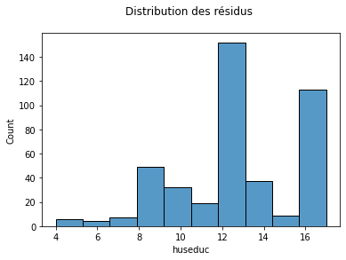

```python
sns.histplot(data = df["huseduc"]).set(title = "Distribution des résidus \n")
print("Valeurs prises par la variable huseduc \n")
print(df.huseduc.value_counts())
```

On remarque que la variable huseduc à pour maximum 17 et minimum 4.

De plus, au regard de l'histogramme il est possible de créer les 4 variables catégorielles de la manière suivante :

- 1 ère variable [4, 7] -> nombre année d'étude faible
- 2 ème variable [8, 11] -> nombre année d'étude moyen
- 3 ème variable [11, 14] -> nombre anné d'étude élevé
- 4 ème variable [14, 17] -> nombre année d'étude très élevé

Toutefois, il existe une fonction en python qui permet de transformer un variable quantitative en un ensemble de variable catégorielle. Il s'agit de la fonction `qcut` de la librairie `pandas`.

```python
df_huseduc_cat = pd.DataFrame(pd.get_dummies(pd.qcut(df.huseduc, 4),prefix='col'))
df_new = pd.concat([df, df_huseduc_cat], axis=1)
df_new = df_new.rename(columns={"col_(3.999, 11.0]": "huseduc_faible",
                                "col_(11.0, 12.0]": "huseduc_moyen",
                                "col_(12.0, 16.0]": "huseduc_eleve",
                                "col_(16.0, 17.0]": "huseduc_tres_eleve"
                               })
df_new.head()
```

|  | inlf | hours | kidslt6 | kidsge6 | age | educ | wage | repwage | hushrs | husage | huseduc | huswage | faminc | mtr | motheduc | fatheduc | unem | city | exper | nwifeinc | lwage | expersq | huseduc_faible | huseduc_moyen | huseduc_eleve | huseduc_tres_eleve |
| --- | --- | --- | --- | --- | --- | --- | --- | --- | --- | --- | --- | --- | --- | --- | --- | --- | --- | --- | --- | --- | --- | --- | --- | --- | --- | --- |
| 0 | 1 | 1610 | 1 | 0 | 32 | 12 | 3.3540 | 2.65 | 2708 | 34 | 12 | 4.0288 | 16310 | 0.7215 | 12 | 7 | 5.0 | 0 | 14 | 10.910060 | 1.210154 | 196 | 0 | 1 | 0 | 0 |
| 1 | 1 | 1656 | 0 | 2 | 30 | 12 | 1.3889 | 2.65 | 2310 | 30 | 9 | 8.4416 | 21800 | 0.6615 | 7 | 7 | 11.0 | 1 | 5 | 19.499980 | 0.328512 | 25 | 1 | 0 | 0 | 0 |
| 2 | 1 | 1980 | 1 | 3 | 35 | 12 | 4.5455 | 4.04 | 3072 | 40 | 12 | 3.5807 | 21040 | 0.6915 | 12 | 7 | 5.0 | 0 | 15 | 12.039910 | 1.514138 | 225 | 0 | 1 | 0 | 0 |
| 3 | 1 | 456 | 0 | 3 | 34 | 12 | 1.0965 | 3.25 | 1920 | 53 | 10 | 3.5417 | 7300 | 0.7815 | 7 | 7 | 5.0 | 0 | 6 | 6.799996 | 0.092123 | 36 | 1 | 0 | 0 | 0 |
| 4 | 1 | 1568 | 1 | 2 | 31 | 14 | 4.5918 | 3.60 | 2000 | 32 | 12 | 10.0000 | 27300 | 0.6215 | 12 | 14 | 9.5 | 1 | 7 | 20.100060 | 1.524272 | 49 | 0 | 1 | 0 | 0 |

**Modèle contraint** :

Ici le modèle contraint correspond au modèle initial

$(constante,city,educ,exper,nwifeinc,kidslt6,kidsge6)$

$y = lwage$

```python
# Etablissement du modèle contraint = modèle initial

constante_new = np.ones(np.shape(lwage))
city_new = df_new["city"]
educ_new = df_new["educ"]
exper_new = df_new["exper"]
nwifeinc_new = df_new["nwifeinc"]
kidslt6_new = df_new["kidslt6"]
kidsge6_new = df_new["kidsge6"]
huseduc_faible = df_new["huseduc_faible"]
huseduc_moyen = df_new["huseduc_moyen"]
huseduc_eleve = df_new["huseduc_eleve"]
huseduc_tres_eleve = df_new["huseduc_tres_eleve"]

# modèle complet : on intègre la variable huseduc au modèle
X_complet = np.column_stack((constante_new,
                     city_new,
                     educ_new,
                     exper_new,
                     nwifeinc_new,
                     kidslt6_new,
                     kidsge6_new,
                    ))

lwage_new = df_new["lwage"]
y_complet = lwage_new

model_complet = sm.OLS(y_complet, X_complet)
results = model_complet.fit()
print(results.summary())
u = results.resid
SSRO=u.T@u
print("SSRO =", SSRO)
```

```
                            OLS Regression Results
==============================================================================
Dep. Variable:                  lwage   R-squared:                       0.156
Model:                            OLS   Adj. R-squared:                  0.144
Method:                 Least Squares   F-statistic:                     12.92
Date:                Wed, 04 May 2022   Prob (F-statistic):           2.00e-13
Time:                        12:06:01   Log-Likelihood:                -431.92
No. Observations:                 428   AIC:                             877.8
Df Residuals:                     421   BIC:                             906.3
Df Model:                           6
Covariance Type:            nonrobust
==============================================================================
                 coef    std err          t      P>|t|      [0.025      0.975]
------------------------------------------------------------------------------
const         -0.3990      0.207     -1.927      0.055      -0.806       0.008
x1             0.0353      0.070      0.503      0.616      -0.103       0.173
x2             0.1022      0.015      6.771      0.000       0.073       0.132
x3             0.0155      0.004      3.452      0.001       0.007       0.024
x4             0.0049      0.003      1.466      0.143      -0.002       0.011
x5            -0.0453      0.085     -0.531      0.596      -0.213       0.122
x6            -0.0117      0.027     -0.434      0.664      -0.065       0.041
==============================================================================
Omnibus:                       79.542   Durbin-Watson:                   1.979
Prob(Omnibus):                  0.000   Jarque-Bera (JB):              287.193
Skew:                          -0.795   Prob(JB):                     4.33e-63
Kurtosis:                       6.685   Cond. No.                         178.
==============================================================================

Warnings:
[1] Standard Errors assume that the covariance matrix of the errors is correctly specified.
SSRO = 188.5899801926394
```

**Modèle complet (i.e non contraint)** :

$(constante, city, educ,exper, nwifeinc, kidslt6,kidsge6, huseducFaible, huseducMoyen, huseducEleve, huseducTresEleve)$

$y = lwage$

```python
# Etablissement du modèle non contraint : on intègre les variables catégorielle huseduc au modèle

X_contraint = np.column_stack((constante_new,
                     city_new,
                     educ_new,
                     exper_new,
                     nwifeinc_new,
                     kidslt6_new,
                     kidsge6_new,
                     huseduc_faible,
                     huseduc_moyen,
                     huseduc_eleve,
                     huseduc_tres_eleve
                    ))

y_contraint = lwage_new

n,k = np.shape(X_contraint)
print("n = ", n)
print("k = ", k)

model_contraint = sm.OLS(y_contraint, X_contraint)
results = model_contraint.fit()
print(results.summary())
u = results.resid
SSR1 = u.T@u
print("SSR1 =", SSR1)
```

```
n =  428
k =  11
                            OLS Regression Results
==============================================================================
Dep. Variable:                  lwage   R-squared:                       0.166
Model:                            OLS   Adj. R-squared:                  0.148
Method:                 Least Squares   F-statistic:                     9.250
Date:                Wed, 04 May 2022   Prob (F-statistic):           7.82e-13
Time:                        12:06:01   Log-Likelihood:                -429.23
No. Observations:                 428   AIC:                             878.5
Df Residuals:                     418   BIC:                             919.1
Df Model:                           9
Covariance Type:            nonrobust
==============================================================================
                 coef    std err          t      P>|t|      [0.025      0.975]
------------------------------------------------------------------------------
const         -0.5423      0.204     -2.664      0.008      -0.942      -0.142
x1             0.0511      0.070      0.726      0.468      -0.087       0.189
x2             0.1184      0.018      6.676      0.000       0.084       0.153
x3             0.0160      0.004      3.569      0.000       0.007       0.025
x4             0.0069      0.003      1.994      0.047    9.72e-05       0.014
x5            -0.0295      0.085     -0.345      0.730      -0.197       0.138
x6            -0.0094      0.027     -0.350      0.726      -0.062       0.043
x7            -0.0676      0.060     -1.120      0.263      -0.186       0.051
x8            -0.0299      0.063     -0.477      0.634      -0.153       0.093
x9            -0.2345      0.087     -2.687      0.008      -0.406      -0.063
x10           -0.2103      0.111     -1.902      0.058      -0.428       0.007
==============================================================================
Omnibus:                       82.181   Durbin-Watson:                   1.964
Prob(Omnibus):                  0.000   Jarque-Bera (JB):              295.700
Skew:                          -0.824   Prob(JB):                     6.16e-65
Kurtosis:                       6.723   Cond. No.                     3.90e+16
==============================================================================

Warnings:
[1] Standard Errors assume that the covariance matrix of the errors is correctly specified.
[2] The smallest eigenvalue is 2.15e-28. This might indicate that there are
strong multicollinearity problems or that the design matrix is singular.
SSR1 = 186.23501394299845
```

#### Calcule de la statistique de Fischer F-stat

```python
F = ((SSR0 - SSR1)/4)/(SSR1/(n-k)) # divise par 4 car on a 4 contraintes (i.e Les 4 variables binaires huseduc)
print("La statistique de Fisher de l'hypothèse jointe est : \n F-stat = ", F)
```

```
La statistique de Fisher de l'hypothèse jointe est :
 F-stat =  1.3182549635924552
```

#### Calcule de la p-valeur

```python
p_val = stats.f.sf(F,4,n-k)
print("La p-valeur de l'hypothèse jointe est \n p-valeur = ", p_val)
```

```
La p-valeur de l'hypothèse jointe est
 p-valeur =  0.26235681163189795
```

### Commentaires

D'un point de vu plus globale, pour ce test au de seuil $\alpha = 5$% on obtient :

- $stat-Fischer = 1.318$
- $p-valeur = 0.262$

On remarque que $p-valeur = 0.262 > \alpha = 0.05$. Donc on ne peut pas rejeter l'hypothèse jointe $H_{0}: \beta_{huseduc} = 0$ à un seuil de **5%** ni même de **10%**.

Par conséquent, on peut en déduire que la variable `huseduc` n'a pas d'effet significatif sur la variable `lwage`. On peut donc en conclure que le niveau d'éduction du mari sur le salaire de son épouse n'est pas significatif.